# RScript accompanying Schmid & Meyer et al. 2023 Mol Ecol

Dominik Schmid & Magdalena Meyer

2023-03-10

```r
#####clean up first####

rm(list=ls())

#####set working directory & read in csv file#####
setwd("~/Dropbox (Personal)/Ghana/02_MHC/working_data")

bats <- read.csv("Revisions/GitHub_Data/Hip_MHC-CoV-data_Schmidetal2023MolEcol.csv", header = TRUE,  sep = ";")

#### turn selected columns into factors ####
bats$species<-as.factor(bats$species)
bats$Location<-as.factor(bats$Location)

#### quadratic term for MHC number
bats$number_ST2<-bats$number_ST^2

##### curate the dataset ####
names(bats)[names(bats) == "X229ELogical"] <- "CoV.229E"
names(bats)[names(bats) == "X2bLogical"] <- "CoV.2B"
names(bats)[names(bats) == "X2bBasalLogical"] <- "CoV.2Bbasal"

# subset datasets for each species for seperate co-occurrence estimates
H.abae<-subset(bats, species=="H.abae")
HipD<-subset(bats, species=="H.cf.ruberD")
HipB<-subset(bats, species=="H.cf.ruberB")
HipC<-subset(bats, species=="H.cf.ruberC")
```

Permanova to determine community differences

```r
####package needed for this section
library(vegan)
#### load host diversity data as wide format
community <- read.csv("~/Dropbox (Personal)/Ghana/02_MHC/working_data/Revisions/GitHub_Data/Hip_community-data_Schmidetal2023MolEcol.csv", header = TRUE, sep=";")

adonis2(community[,c(3,5:7)]~ Location , data= community, permutations = 999, method = "manhattan")
```

```
## Permutation test for adonis under reduced model
## Terms added sequentially (first to last)
## Permutation: free
## Number of permutations: 999
##
## adonis2(formula = community[, c(3, 5:7)] ~ Location, data = community, permutations = 999, method = "manhattan")
##            Df SumOfSqs      R2      F Pr(>F)
## Location    4   243.64 0.09728 69.909  0.001 ***
## Residual 2595  2260.99 0.90272
## Total    2599  2504.64 1.00000
## ---
## Signif. codes:  0 '***' 0.001 '**' 0.01 '*' 0.05 '.' 0.1 ' ' 1
```

pie charts for Figure 1A

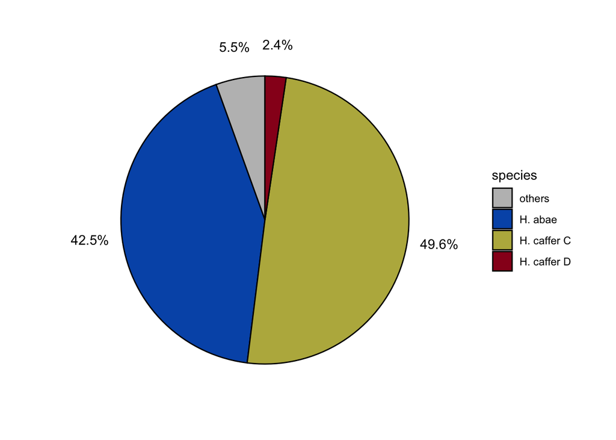

```r
library(plyr)
library(ggplot2)

comm <- read.csv("~/Dropbox (Personal)/Ghana/02_MHC/working_data/Revisions/GitHub_Data/Hip_community-CoV-data_Schmidetal2023MolEcol.csv", header = TRUE,  sep = ";")

comm$species<-as.factor(comm$Species)
comm$Location<-as.factor(comm$Location)


levels(comm$species) = c("others", "H. abae", "others", "H. caffer B", "H. caffer C","H. caffer D","others", "others", "others", "others", "others", "others","others", "others", "others")

AT<-subset(comm, Location=="Akpafu Todzi")
BUO<-subset(comm, Location=="Buoyem")
FOR<-subset(comm, Location=="Forikrom")
KW<-subset(comm, Location=="Kwamang")
LT<-subset(comm, Location=="Likpe Todome")

###### AT ######
AT_sums<-ddply(AT, c("species"), summarise,
               count=length(species))
AT_sums$countT<-sum(AT_sums$count)
AT_sums$perc <- round(AT_sums$count/AT_sums$countT,4)
AT_sums$labels = scales::percent(AT_sums$perc)


ggplot(AT_sums, aes(x = "", y = perc, fill = species)) +
  geom_col(color = "black") +
  geom_text(aes(x=1.65, label = labels),
            position = position_stack(vjust = .5),
            show.legend = FALSE) +
  guides(fill = guide_legend(title = "species")) +
  scale_fill_manual(values=c("grey", "#0157b6", "#b9b44c", "#98001f")) +
  coord_polar(theta = "y") +
  theme_void()
```

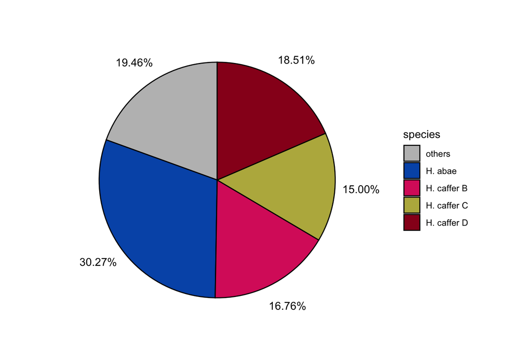

```r
############# BUO cave ##################

BUO_sums<-ddply(BUO, c("species"), summarise,
                count=length(species))
BUO_sums$countT<-sum(BUO_sums$count)
BUO_sums$perc <- round(BUO_sums$count/BUO_sums$countT,4)
BUO_sums$labels = scales::percent(BUO_sums$perc)



ggplot(BUO_sums, aes(x = "", y = perc, fill = species)) +
  geom_col(color = "black") +
  geom_text(aes(x=1.65, label = labels),
            position = position_stack(vjust = .5),
            show.legend = FALSE) +
  guides(fill = guide_legend(title = "species")) +
  scale_fill_manual(values=c("grey", "#0157b6", "#da286a","#b9b44c", "#98001f")) +
  coord_polar(theta = "y") +
  theme_void()
```

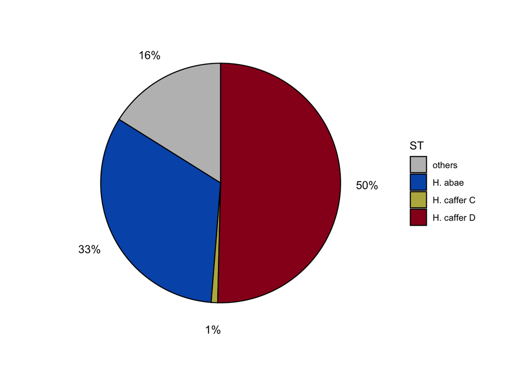

```r
############## KW Cave next ####################

KW_sums<-ddply(KW, c("species"), summarise,
               count=length(species))
KW_sums$countT<-sum(KW_sums$count)
KW_sums$perc <- round(KW_sums$count/KW_sums$countT,4)
KW_sums$labels = scales::percent(KW_sums$perc)



ggplot(KW_sums, aes(x = "", y = perc, fill = species)) +
  geom_col(color = "black") +
  geom_text(aes(x=1.65, label = labels),
            position = position_stack(vjust = .5),
            show.legend = FALSE) +
  guides(fill = guide_legend(title = "ST")) +
  scale_fill_manual(values=c("grey", "#0157b6","#b9b44c", "#98001f")) +
  coord_polar(theta = "y") +
  theme_void()
```

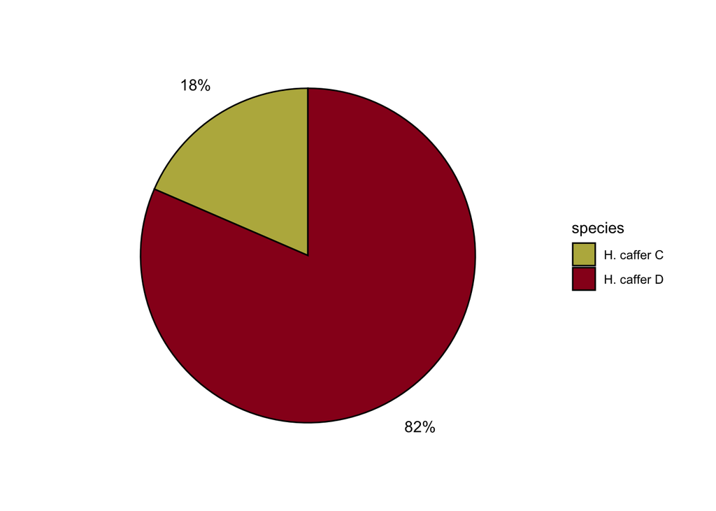

```r
######## LT cave ###########

LT_sums<-ddply(LT, c("species"), summarise,
               count=length(species))
LT_sums$countT<-sum(LT_sums$count)
LT_sums$perc <- round(LT_sums$count/LT_sums$countT,3)
LT_sums$labels = scales::percent(LT_sums$perc)



ggplot(LT_sums, aes(x = "", y = perc, fill = species)) +
  geom_col(color = "black") +
  geom_text(aes(x=1.65, label = labels),
            position = position_stack(vjust = .5),
            show.legend = FALSE) +
  guides(fill = guide_legend(title = "species")) +
  scale_fill_manual(values=c("#b9b44c", "#98001f")) +
  coord_polar(theta = "y") +
  theme_void()
```

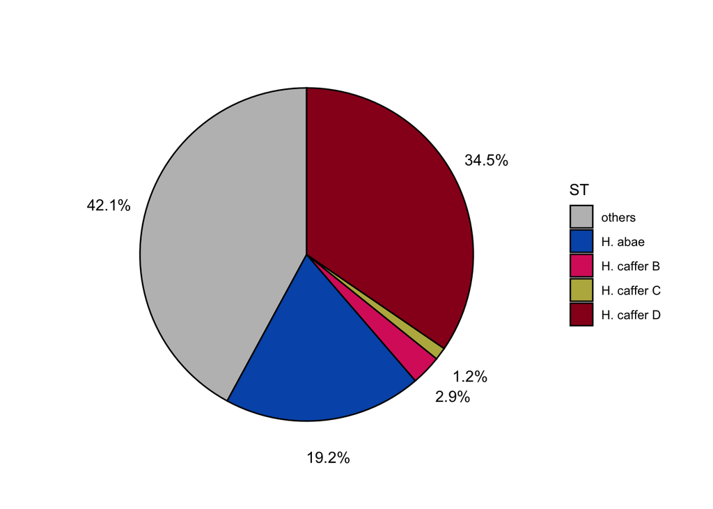

```r
######## FOR cave ###########

FOR_sums<-ddply(FOR, c("species"), summarise,
                count=length(species))
FOR_sums$countT<-sum(FOR_sums$count)
FOR_sums$perc <- round(FOR_sums$count/FOR_sums$countT,4)
FOR_sums$labels = scales::percent(FOR_sums$perc)



ggplot(FOR_sums, aes(x = "", y = perc, fill = species)) +
  geom_col(color = "black") +
  geom_text(aes(x=1.65, label = labels),
            position = position_stack(vjust = .5),
            show.legend = FALSE) +
  guides(fill = guide_legend(title = "ST")) +
  scale_fill_manual(values=c("grey", "#0157b6", "#da286a","#b9b44c", "#98001f")) +
  coord_polar(theta = "y") +
  theme_void()
```

Figure 1 B

```r
library(dplyr)
```

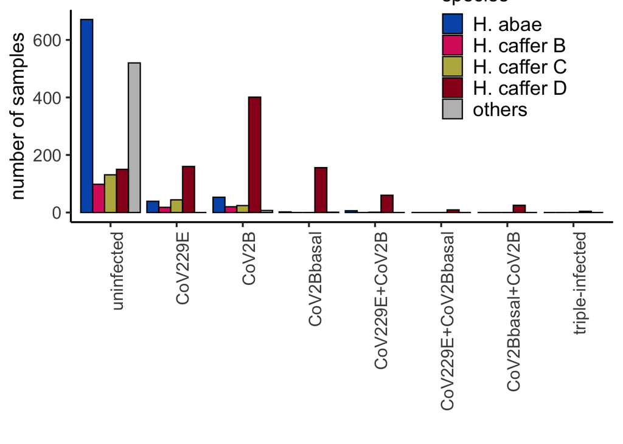

```r
library(forcats)

comm$coinfection2 = as.factor(
   paste(comm$X229ELogical,comm$X2bLogical,comm$X2bBasalLogical,sep=""))

#levels(sample_data(bats)$coinfection2)
levels(comm$coinfection2) = c("uninfected", "CoV2Bbasal",
                              "CoV2B", "CoV2Bbasal+CoV2B",
                              "CoV229E","CoV229E+CoV2Bbasal",
                              "CoV229E+CoV2B", "triple-infected")

comm_plot_dat<-ddply(comm, c("species", "coinfection2"), summarise, n=length(coinfection2))
##### inset rows for missing categories for better visualisation
comm_plot_dat<- comm_plot_dat %>% add_row(species = "H. caffer B", coinfection2="CoV2Bbasal", n = 0)
comm_plot_dat<- comm_plot_dat %>% add_row(species = "H. caffer B", coinfection2="CoV229E+CoV2B", n = 0)
comm_plot_dat<- comm_plot_dat %>% add_row(species = "H. caffer B", coinfection2="CoV2Bbasal+CoV2B", n = 0)
comm_plot_dat<- comm_plot_dat %>% add_row(species = "H. caffer B", coinfection2="CoV229E+CoV2Bbasal", n = 0)
comm_plot_dat<- comm_plot_dat %>% add_row(species = "H. caffer B", coinfection2="triple-infected", n = 0)
comm_plot_dat<- comm_plot_dat %>% add_row(species = "H. caffer C", coinfection2="CoV2Bbasal", n = 0)
comm_plot_dat<- comm_plot_dat %>% add_row(species = "H. caffer C", coinfection2="CoV2Bbasal+CoV2B", n = 0)
comm_plot_dat<- comm_plot_dat %>% add_row(species = "H. caffer C", coinfection2="triple-infected", n = 0)
comm_plot_dat<- comm_plot_dat %>% add_row(species = "H. caffer C", coinfection2="CoV229E+CoV2Bbasal", n = 0)
comm_plot_dat<- comm_plot_dat %>% add_row(species = "H. abae", coinfection2="triple-infected", n = 0)
comm_plot_dat<- comm_plot_dat %>% add_row(species = "H. abae", coinfection2="CoV229E+CoV2Bbasal", n = 0)
comm_plot_dat<- comm_plot_dat %>% add_row(species = "H. abae", coinfection2="CoV2Bbasal+CoV2B", n = 0)
comm_plot_dat<- comm_plot_dat %>% add_row(species = "others", coinfection2="triple-infected", n = 0)
comm_plot_dat<- comm_plot_dat %>% add_row(species = "others", coinfection2="CoV229E+CoV2Bbasal", n = 0)
comm_plot_dat<- comm_plot_dat %>% add_row(species = "others", coinfection2="CoV2Bbasal+CoV2B", n = 0)
comm_plot_dat<- comm_plot_dat %>% add_row(species = "others", coinfection2="CoV229E", n = 0)
comm_plot_dat<- comm_plot_dat %>% add_row(species = "others", coinfection2="CoV229E+CoV2B", n = 0)

ggplot(comm_plot_dat, aes(fct_relevel(coinfection2, "uninfected", "CoV229E", "CoV2B", "CoV2Bbasal", "CoV229E+CoV2B", "CoV229E+CoV2Bbasal", "CoV2Bbasal+CoV2B", "triple-infected"), n, fill=species))+
  geom_bar(stat="identity", position = position_dodge(0.9), colour="black")+
  scale_fill_manual(values=c("#0157b6", "#da286a","#b9b44c", "#98001f","grey" ))+ylab("number of samples")+
  theme_classic(base_size = 16)+ theme(legend.position = c(0.8,0.8), legend.text = element_text(size=16), legend.title = element_text(size=16), axis.text.x = element_text(size=14, angle = 90, vjust = 1, hjust=1), axis.text = element_text(size=14))+xlab("")
```

###### x2-test to compare differences in infection patterns between species

```r
bats_con.tab<-table(comm$Species, comm$coinfection2)
bats_con.tab<-bats_con.tab[-c(1,3,7:15),]

chisq.test(bats_con.tab)
```

```
##
##  Pearson's Chi-squared test
##
## data:  bats_con.tab
## X-squared = 1019.1, df = 21, p-value < 2.2e-16
```

Summaries of MHC diversity between species and locations

```r
library(plyr)

#### summary stats by species
ddply(bats, c("species"), summarise,
      n=length(species),
      mean_allele=mean(number_alleles),
      median=median(number_alleles),
      sd_allele=sd(number_alleles),
      mean_ST=mean(number_ST),
      median_ST=median(number_ST),
      sd_ST=sd(number_ST))
```

```
##       species   n mean_allele median sd_allele  mean_ST median_ST     sd_ST
## 1      H.abae 111    3.801802    4.0  1.142723 3.333333         3 1.0209918
## 2 H.cf.ruberB  76    5.250000    5.0  2.085665 4.223684         4 1.4009395
## 3 H.cf.ruberC 146    5.157534    5.0  2.056741 3.636986         4 1.2477850
## 4 H.cf.ruberD 236    5.211864    4.5  2.139205 3.305085         3 0.9807377
```

```r
#### summary stats by location
ddply(bats, c("Location"), summarise,
      n=length(Location),
      mean_allele=mean(number_alleles),
      median=median(number_alleles),
      sd_allele=sd(number_alleles),
      mean_ST=mean(number_ST),
      median_ST=median(number_ST),
      sd_ST=sd(number_ST))
```

```
##       Location   n mean_allele median sd_allele  mean_ST median_ST     sd_ST
## 1 Akpafu Todzi  74    4.324324      4  1.647814 3.554054         3 1.3048056
## 2       Buoyem 195    5.338462      5  2.191433 3.882051         4 1.2768501
## 3     Forikrom  51    5.784314      7  2.532301 3.098039         3 1.0631068
## 4      Kwamang 231    4.588745      4  1.754412 3.298701         3 0.9564191
## 5 Likpe Todome  18    4.888889      4  1.745208 3.444444         3 0.9217772
```

```r
#### by interaction between species & location
ddply(bats, c("species","Location"), summarise,
      n=length(species),
      mean_allele=mean(number_alleles),
      median=median(number_alleles),
      sd_allele=sd(number_alleles),
      mean_ST=mean(number_ST),
      sd_ST=sd(number_ST))
```

```
##        species     Location   n mean_allele median sd_allele  mean_ST     sd_ST
## 1       H.abae Akpafu Todzi  16    3.625000      4 1.5000000 2.875000 1.0246951
## 2       H.abae       Buoyem  24    4.125000      4 0.8998792 3.791667 0.9770927
## 3       H.abae     Forikrom   8    3.750000      4 1.2817399 3.250000 0.8864053
## 4       H.abae      Kwamang  63    3.730159      4 1.1101634 3.285714 1.0068887
## 5  H.cf.ruberB       Buoyem  71    5.408451      5 2.0324332 4.309859 1.3584818
## 6  H.cf.ruberB     Forikrom   5    3.000000      3 1.5811388 3.000000 1.5811388
## 7  H.cf.ruberC Akpafu Todzi  57    4.543860      4 1.6482694 3.754386 1.3266594
## 8  H.cf.ruberC       Buoyem  68    5.794118      5 2.2563927 3.764706 1.1475821
## 9  H.cf.ruberC     Forikrom   4    3.250000      3 1.2583057 2.500000 1.2909944
## 10 H.cf.ruberC      Kwamang   9    5.444444      5 2.0069324 2.555556 0.8819171
## 11 H.cf.ruberC Likpe Todome   8    4.750000      4 1.5811388 3.500000 1.1952286
## 12 H.cf.ruberD Akpafu Todzi   1    3.000000      3        NA 3.000000        NA
## 13 H.cf.ruberD       Buoyem  32    5.125000      4 2.7327170 3.250000 1.2700013
## 14 H.cf.ruberD     Forikrom  34    6.970588      7 2.1246789 3.147059 1.0189821
## 15 H.cf.ruberD      Kwamang 159    4.880503      4 1.8362206 3.345912 0.9276854
## 16 H.cf.ruberD Likpe Todome  10    5.000000      4 1.9436506 3.400000 0.6992059
```

```r
mod1xLoc_Spec<-(glm(number_alleles ~ Location * species , data=bats, family=poisson()))
summary(mod1xLoc_Spec)
```

```
##
## Call:
## glm(formula = number_alleles ~ Location * species, family = poisson(),
##     data = bats)
##
## Deviance Residuals:
##      Min        1Q    Median        3Q       Max
## -2.46466  -0.58248  -0.06186   0.48495   2.71161
##
## Coefficients: (4 not defined because of singularities)
##                                         Estimate Std. Error z value Pr(>|z|)
## (Intercept)                               1.2878     0.1313   9.808   <2e-16
## LocationBuoyem                            0.1292     0.1654   0.781    0.435
## LocationForikrom                          0.0339     0.2249   0.151    0.880
## LocationKwamang                           0.0286     0.1466   0.195    0.845
## LocationLikpe Todome                      0.5108     0.5944   0.859    0.390
## speciesH.cf.ruberB                       -0.2231     0.3162  -0.706    0.480
## speciesH.cf.ruberC                        0.2259     0.1453   1.555    0.120
## speciesH.cf.ruberD                       -0.1892     0.5921  -0.320    0.749
## LocationBuoyem:speciesH.cf.ruberB         0.4940     0.3357   1.472    0.141
## LocationForikrom:speciesH.cf.ruberB           NA         NA      NA       NA
## LocationKwamang:speciesH.cf.ruberB            NA         NA      NA       NA
## LocationLikpe Todome:speciesH.cf.ruberB       NA         NA      NA       NA
## LocationBuoyem:speciesH.cf.ruberC         0.1139     0.1837   0.620    0.535
## LocationForikrom:speciesH.cf.ruberC      -0.3690     0.3624  -1.018    0.309
## LocationKwamang:speciesH.cf.ruberC        0.1522     0.2139   0.712    0.477
## LocationLikpe Todome:speciesH.cf.ruberC  -0.4665     0.6193  -0.753    0.451
## LocationBuoyem:speciesH.cf.ruberD         0.4063     0.6056   0.671    0.502
## LocationForikrom:speciesH.cf.ruberD       0.8092     0.6230   1.299    0.194
## LocationKwamang:speciesH.cf.ruberD        0.4580     0.5968   0.768    0.443
## LocationLikpe Todome:speciesH.cf.ruberD       NA         NA      NA       NA
##
## (Intercept)                             ***
## LocationBuoyem
## LocationForikrom
## LocationKwamang
## LocationLikpe Todome
## speciesH.cf.ruberB
## speciesH.cf.ruberC
## speciesH.cf.ruberD
## LocationBuoyem:speciesH.cf.ruberB
## LocationForikrom:speciesH.cf.ruberB
## LocationKwamang:speciesH.cf.ruberB
## LocationLikpe Todome:speciesH.cf.ruberB
## LocationBuoyem:speciesH.cf.ruberC
## LocationForikrom:speciesH.cf.ruberC
## LocationKwamang:speciesH.cf.ruberC
## LocationLikpe Todome:speciesH.cf.ruberC
## LocationBuoyem:speciesH.cf.ruberD
## LocationForikrom:speciesH.cf.ruberD
## LocationKwamang:speciesH.cf.ruberD
## LocationLikpe Todome:speciesH.cf.ruberD
## ---
## Signif. codes:  0 '***' 0.001 '**' 0.01 '*' 0.05 '.' 0.1 ' ' 1
##
## (Dispersion parameter for poisson family taken to be 1)
##
##     Null deviance: 457.20  on 568  degrees of freedom
## Residual deviance: 376.33  on 553  degrees of freedom
## AIC: 2335.8
##
## Number of Fisher Scoring iterations: 4
```

```r
mod2xLoc_Spec<-(glm(number_ST ~ Location * species, data=bats, family=poisson()))
summary(mod2xLoc_Spec)
```

```
##
## Call:
## glm(formula = number_ST ~ Location * species, family = poisson(),
##     data = bats)
##
## Deviance Residuals:
##     Min       1Q   Median       3Q      Max
## -1.9230  -0.4036  -0.1405   0.3468   1.4935
##
## Coefficients: (4 not defined because of singularities)
##                                         Estimate Std. Error z value Pr(>|z|)
## (Intercept)                              1.05605    0.14744   7.163 7.92e-13
## LocationBuoyem                           0.27675    0.18091   1.530    0.126
## LocationForikrom                         0.12260    0.24536   0.500    0.617
## LocationKwamang                          0.13353    0.16300   0.819    0.413
## LocationLikpe Todome                     0.12516    0.60228   0.208    0.835
## speciesH.cf.ruberB                      -0.08004    0.32423  -0.247    0.805
## speciesH.cf.ruberC                       0.26687    0.16252   1.642    0.101
## speciesH.cf.ruberD                       0.04256    0.59588   0.071    0.943
## LocationBuoyem:speciesH.cf.ruberB        0.20814    0.34552   0.602    0.547
## LocationForikrom:speciesH.cf.ruberB           NA         NA      NA       NA
## LocationKwamang:speciesH.cf.ruberB            NA         NA      NA       NA
## LocationLikpe Todome:speciesH.cf.ruberB       NA         NA      NA       NA
## LocationBuoyem:speciesH.cf.ruberC       -0.27401    0.20324  -1.348    0.178
## LocationForikrom:speciesH.cf.ruberC     -0.52924    0.40604  -1.303    0.192
## LocationKwamang:speciesH.cf.ruberC      -0.51819    0.27335  -1.896    0.058
## LocationLikpe Todome:speciesH.cf.ruberC -0.19532    0.63493  -0.308    0.758
## LocationBuoyem:speciesH.cf.ruberD       -0.19671    0.61292  -0.321    0.748
## LocationForikrom:speciesH.cf.ruberD     -0.07475    0.63473  -0.118    0.906
## LocationKwamang:speciesH.cf.ruberD      -0.02440    0.60148  -0.041    0.968
## LocationLikpe Todome:speciesH.cf.ruberD       NA         NA      NA       NA
##
## (Intercept)                             ***
## LocationBuoyem
## LocationForikrom
## LocationKwamang
## LocationLikpe Todome
## speciesH.cf.ruberB
## speciesH.cf.ruberC
## speciesH.cf.ruberD
## LocationBuoyem:speciesH.cf.ruberB
## LocationForikrom:speciesH.cf.ruberB
## LocationKwamang:speciesH.cf.ruberB
## LocationLikpe Todome:speciesH.cf.ruberB
## LocationBuoyem:speciesH.cf.ruberC
## LocationForikrom:speciesH.cf.ruberC
## LocationKwamang:speciesH.cf.ruberC      .
## LocationLikpe Todome:speciesH.cf.ruberC
## LocationBuoyem:speciesH.cf.ruberD
## LocationForikrom:speciesH.cf.ruberD
## LocationKwamang:speciesH.cf.ruberD
## LocationLikpe Todome:speciesH.cf.ruberD
## ---
## Signif. codes:  0 '***' 0.001 '**' 0.01 '*' 0.05 '.' 0.1 ' ' 1
##
## (Dispersion parameter for poisson family taken to be 1)
##
##     Null deviance: 225.83  on 568  degrees of freedom
## Residual deviance: 200.46  on 553  degrees of freedom
## AIC: 1989.4
##
## Number of Fisher Scoring iterations: 4
```

Co-occurence

THE FOLLOWING IS FOR H.abae COOCCURANCE WITH SUPERTYPES

```r
##### libraries for this section #####
library(cooccur)
library(tidyr)
library(ggplot2)
library(hrbrthemes)
library(RColorBrewer)
library(tidyverse)
```

here we calculate the co-occurence results for each species sperately

```r
# for co-occurence analyses all columns you want to test for associations need to be binary (1=presence / 0=absence)

# co-occurrence analysis of common mhc STs and coronavirus
# we define common STs as all mhc STs that occur in at least 10 individuals

# first select all columns with allele and virus info we want to investigate for co-occurrence
cooccur_H.abae <-subset(H.abae, select=c("CoV.229E","CoV.2B","CoV.2Bbasal",
                                "ST1", "ST2", "ST3", "ST4", "ST7", "ST10", "ST11", "ST12"))

# create a transposed matrix
cooccur_H.abae_long <- t(as.matrix(cooccur_H.abae))

# now apply the co-occurrence function
# just fyi when you look up the cooccurr package it shows co-occurrence of "species" and "sites",
# and these terms are also used within the function
# so here the "species" are alleles and pathogens and the "sites" are the individuals

H.abae_STs <- cooccur(mat = cooccur_H.abae_long, type = "spp_site", thresh = FALSE, spp_names = TRUE)
```

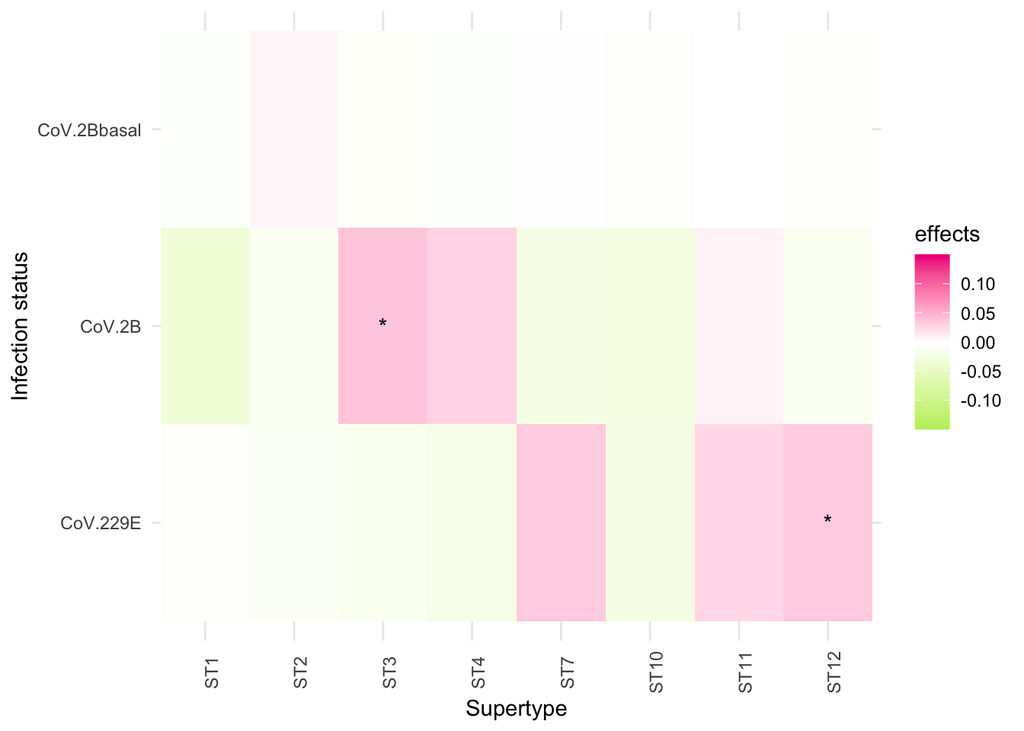

```r
# which supertypes have a positive or negative association with infection status
#pair(mod = H.abae_STs, "CoV.229E")
#pair(mod = H.abae_STs, "CoV.2B")
#pair(mod = H.abae_STs, "CoV.2Bbasal")

complete_H.abae_STs<-prob.table(H.abae_STs) # table of expected & observed cooccurrence and p-values for all comparisons

# standardise effect sizes and add it to df
effectsize_h.abae  <- effect.sizes(H.abae_STs, standardized = TRUE, matrix = FALSE)
complete_H.abae_STs$effects <- effectsize_h.abae$effects

### prepare heat map plot for each infection
heatmap.dat<-subset(complete_H.abae_STs, sp1_name=="CoV.229E" | sp1_name=="CoV.2B" | sp1_name=="CoV.2Bbasal")

#### remove double ups ####
heatmap.dat<-subset(heatmap.dat, sp2_name!="CoV.2B")
heatmap.dat<-subset(heatmap.dat, sp2_name!="CoV.2Bbasal")

#### specify asterix assignment for
heatmap.dat.p_gt <- heatmap.dat %>%
  mutate(Asterisks_gt = ifelse(p_gt  <= 0.001, "***",
                            ifelse(p_gt <= 0.01, "**",
                                   ifelse(p_gt  <= 0.05, "*", NA))))
heatmap.dat.p_lt <- heatmap.dat %>%
  mutate(Asterisks_lt = ifelse(p_lt  <= 0.001, "***",
                            ifelse(p_lt <= 0.01, "**",
                                   ifelse(p_lt  <= 0.05, "*", NA))))

#### construct ggplot heatmap
ggplot(heatmap.dat, aes(sp2_name, sp1_name, fill=effects)) +
  geom_tile()+
  scale_fill_gradient2(high="deeppink2", mid="white", low="darkolivegreen2", limits = c(-0.15, 0.15))+
  theme_minimal()+
  scale_x_discrete(limits = c("ST1", "ST2", "ST3", "ST4","ST7", "ST10", "ST11","ST12"))+
  theme(axis.text.x = element_text(angle = 90))+
  ylab("Infection status")+xlab("Supertype")+
  geom_text(data = heatmap.dat.p_gt, aes(x = sp2_name, y = sp1_name, label = Asterisks_gt), size = 4)+
  geom_text(data = heatmap.dat.p_lt, aes(x = sp2_name, y = sp1_name, label = Asterisks_lt), size = 4)
```

based on the co-occurence analysis some associations were found for Hipposideros abae: CoV2B was positively associated with ST3 CoV229E was positively associated with ST12

We now repeat the co-occurence analysis for all other bat species

THE FOLLOWING IS FOR Hipposideros D COOCCURANCE WITH SUPERTYPES

```r
cooccur_HipD <-subset(HipD, select=c("CoV.229E","CoV.2B","CoV.2Bbasal",
                                     "ST1","ST2","ST3","ST5","ST7","ST8","ST9","ST10","ST11","ST12"))
# create a transposed matrix
cooccur_HipD_long <- t(as.matrix(cooccur_HipD))


# now apply the co-occurrence function
HipD_STs <- cooccur(mat = cooccur_HipD_long, type = "spp_site", thresh = FALSE, spp_names = TRUE)
```

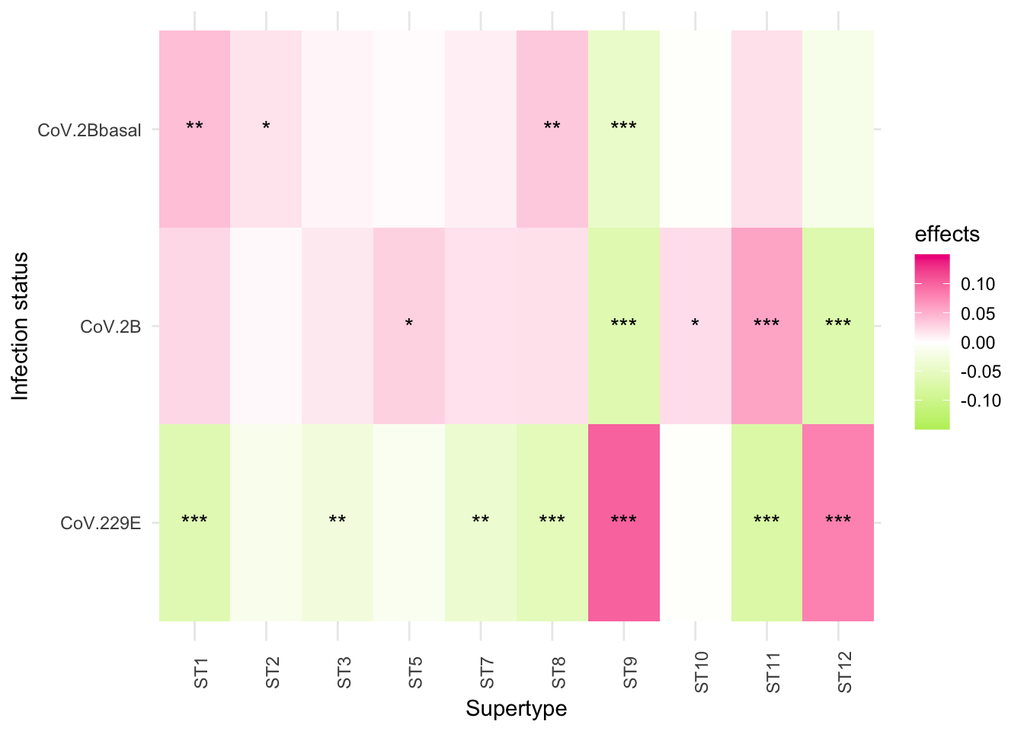

```r
# which supertypes have a positive or negative association with infection status
#pair(mod = HipD_STs, "CoV.229E")
#pair(mod = HipD_STs, "CoV.2B")
#pair(mod = HipD_STs, "CoV.2Bbasal")

complete_HipD_STs<-prob.table(HipD_STs)

# calculate standardized effect sizes
effectsize_hipD  <- effect.sizes(HipD_STs, standardized = TRUE, matrix = FALSE)
complete_HipD_STs$effects <- effectsize_hipD$effects

### prepare heat map plot for each infection
heatmap.dat<-subset(complete_HipD_STs, sp1_name=="CoV.229E" | sp1_name=="CoV.2B" | sp1_name=="CoV.2Bbasal")

#remove double ups
heatmap.dat<-subset(heatmap.dat, sp2_name!="CoV.2B")
heatmap.dat<-subset(heatmap.dat, sp2_name!="CoV.2Bbasal")

#### specify asterix assignment for
heatmap.dat.p_gt <- heatmap.dat %>%
  mutate(Asterisks_gt = ifelse(p_gt  <= 0.001, "***",
                            ifelse(p_gt <= 0.01, "**",
                                   ifelse(p_gt  <= 0.05, "*", NA))))
heatmap.dat.p_lt <- heatmap.dat %>%
  mutate(Asterisks_lt = ifelse(p_lt  <= 0.001, "***",
                            ifelse(p_lt <= 0.01, "**",
                                   ifelse(p_lt  <= 0.05, "*", NA))))

#construct heatmap
ggplot(heatmap.dat, aes(sp2_name, sp1_name, fill=effects)) +
  geom_tile()+
  scale_fill_gradient2(high="deeppink2", mid="white", low="darkolivegreen2",
                       limits = c(-0.15, 0.15)
                       )+theme_minimal()+
  scale_x_discrete(limits = c("ST1", "ST2", "ST3", "ST5","ST7", "ST8", "ST9","ST10", "ST11","ST12"))+
  theme(axis.text.x = element_text(angle = 90))+
  ylab("Infection status")+xlab("Supertype")+
  geom_text(data = heatmap.dat.p_gt, aes(x = sp2_name, y = sp1_name, label = Asterisks_gt), size = 4)+
  geom_text(data = heatmap.dat.p_lt, aes(x = sp2_name, y = sp1_name, label = Asterisks_lt), size = 4)
```

based on the co-occurence analysis many associations were found for Hipposideros D: CoV2Bbasal was positively associated with ST1, ST2, and ST8, but negatively with ST9 CoV2B was positively associated with ST5, ST10 and ST11, but negatively with ST9 and ST12 CoV229E was negatively associated with ST1, ST3, ST7, ST8 and ST11, but positively with ST9 and ST12

THE FOLLOWING IS FOR Hipposideros C COOCCURANCE WITH SUPERTYPES

```r
### C is never infected with 2B basal so this is removed from the list
cooccur_HipC <-subset(HipC, select=c("CoV.229E","CoV.2B",
                                     "ST1","ST2","ST3","ST4","ST5","ST6","ST7","ST8","ST10","ST11","ST12"))

# create a transposed matrix
cooccur_HipC_long <- t(as.matrix(cooccur_HipC))


# now apply the co-occurrence function
HipC_STs <- cooccur(mat = cooccur_HipC_long, type = "spp_site", thresh = FALSE, spp_names = TRUE)
```

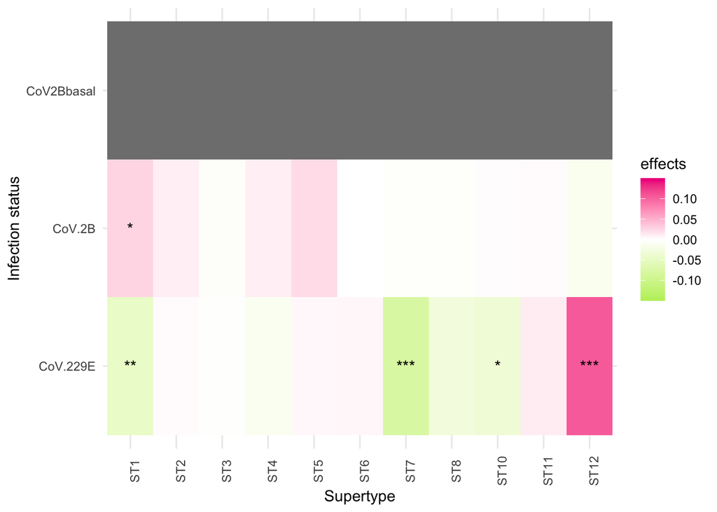

```r
# which supertypes have a positive or negative association with infection status
#pair(mod = HipC_STs, "CoV.229E")
#pair(mod = HipC_STs, "CoV.2B")

complete_HipC_STs<-prob.table(HipC_STs)

#calculate standardised effect sizes
effectsize_hipC  <- effect.sizes(HipC_STs, standardized = TRUE, matrix = FALSE)
complete_HipC_STs$effects <- effectsize_hipC$effects

# prepare heat map plot for all infections
heatmap.dat<-subset(complete_HipC_STs, sp1_name=="CoV.229E" | sp1_name=="CoV.2B")

#remove double ups
heatmap.dat<-subset(heatmap.dat, sp2_name!="CoV.2B")

####making an NA column for 2Bbasal #####
basal.dat <- subset(heatmap.dat, sp1_name=="CoV.2B")
basal.dat$sp1_name <- "CoV2Bbasal"
basal.dat$effects <- NA
### not elegant but it works

# sepfifying asterix assignment
heatmap.dat.p_gt <- heatmap.dat %>%
  mutate(Asterisks_gt = ifelse(p_gt  <= 0.001, "***",
                               ifelse(p_gt <= 0.01, "**",
                                      ifelse(p_gt  <= 0.05, "*", NA))))
heatmap.dat.p_lt <- heatmap.dat %>%
  mutate(Asterisks_lt = ifelse(p_lt  <= 0.001, "***",
                               ifelse(p_lt <= 0.01, "**",
                                      ifelse(p_lt  <= 0.05, "*", NA))))

#fuse artifical basal data with heat.map data
heatmap.dat<-rbind(heatmap.dat, basal.dat)

ggplot(heatmap.dat, aes(sp2_name, sp1_name, fill=effects)) +
  geom_tile()+
  scale_fill_gradient2(high="deeppink2", mid="white", low="darkolivegreen2",
                       limits = c(-0.15, 0.15)
  )+theme_minimal()+
  scale_x_discrete(limits = c("ST1", "ST2", "ST3", "ST4", "ST5", "ST6", "ST7", "ST8","ST10", "ST11","ST12"))+
  theme(axis.text.x = element_text(angle = 90))+
  ylab("Infection status")+xlab("Supertype")+
  geom_text(data = heatmap.dat.p_gt, aes(x = sp2_name, y = sp1_name, label = Asterisks_gt), size = 4)+
  geom_text(data = heatmap.dat.p_lt, aes(x = sp2_name, y = sp1_name, label = Asterisks_lt), size = 4)
```

THE FOLLOWING IS FOR Hipposideros B COOCCURANCE WITH SUPERTYPES

```r
# 2Bbasal is also not ever observed in Hipposideros B
cooccur_HipB <-subset(HipB, select=c("CoV.229E","CoV.2B",
                                     "ST1","ST2","ST4","ST5","ST7","ST8","ST9","ST10","ST11","ST12"))

# create a transposed matrix
cooccur_HipB_long <- t(as.matrix(cooccur_HipB))


# now apply the co-occurrence function
HipB_STs <- cooccur(mat = cooccur_HipB_long, type = "spp_site", thresh = FALSE, spp_names = TRUE)
```

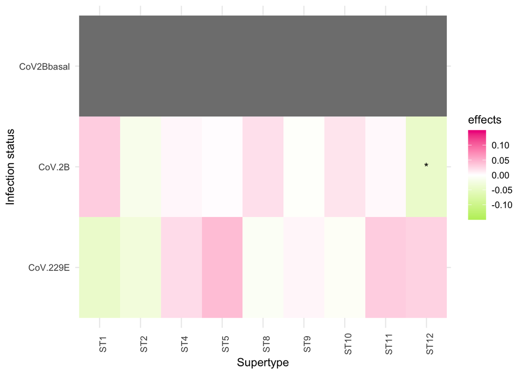

```r
# which supertypes have a positive or negative association with infection status
#pair(mod = HipB_STs, "CoV.229E")
#pair(mod = HipB_STs, "CoV.2B")

complete_HipB_STs<-prob.table(HipB_STs)

#calculate effect sizes
effectsize_hipB  <- effect.sizes(HipB_STs, standardized = TRUE, matrix = FALSE)
complete_HipB_STs$effects <- effectsize_hipB$effects

# prepare heatmap data
heatmap.dat<-subset(complete_HipB_STs, sp1_name=="CoV.229E" | sp1_name=="CoV.2B")

#remove double ups
heatmap.dat<-subset(heatmap.dat, sp2_name!="CoV.2B")

####making an NA column for 2Bbasal #####
basal.dat <- subset(heatmap.dat, sp1_name=="CoV.2B")
basal.dat$sp1_name <- "CoV2Bbasal"
basal.dat$effects <- NA

# secify asterix assignment
heatmap.dat.p_gt <- heatmap.dat %>%
  mutate(Asterisks_gt = ifelse(p_gt  <= 0.001, "***",
                               ifelse(p_gt <= 0.01, "**",
                                      ifelse(p_gt  <= 0.05, "*", NA))))
heatmap.dat.p_lt <- heatmap.dat %>%
  mutate(Asterisks_lt = ifelse(p_lt  <= 0.001, "***",
                               ifelse(p_lt <= 0.01, "**",
                                      ifelse(p_lt  <= 0.05, "*", NA))))

#merge artificial basal data with heatmap data
heatmap.dat<-rbind(heatmap.dat, basal.dat)

ggplot(heatmap.dat, aes(sp2_name, sp1_name, fill=effects)) +
  geom_tile()+
  scale_fill_gradient2(high="deeppink2", mid="white", low="darkolivegreen2",
                       limits = c(-0.15, 0.15)
  )+theme_minimal()+
  scale_x_discrete(limits = c("ST1", "ST2", "ST4", "ST5", "ST8", "ST9","ST10", "ST11","ST12"))+
  theme(axis.text.x = element_text(angle = 90))+
  ylab("Infection status")+xlab("Supertype")+
  geom_text(data = heatmap.dat.p_gt, aes(x = sp2_name, y = sp1_name, label = Asterisks_gt), size = 4)+
  geom_text(data = heatmap.dat.p_lt, aes(x = sp2_name, y = sp1_name, label = Asterisks_lt), size = 4)
```

confirmatory generalised linear mixed effect models

following from the results of the cooccurence analysis we identfied several STs to be possibly associated with infections, but conservatively we estimated this required further confirmation in models that include other possible explanatory variables and account for variation between sampling location and capture period

```r
###load libraries for this section
library(lmerTest)
```

```r
library(lme4)
library(MuMIn)
library(sjPlot)
### based on the co-occurence test we targeted specific MHC alleles and tested in a species-specific GLM ...
### that included number of MHC STs (and its quadratic term) whether specific STs ...
### explained infections with CoV229E, CoV2B and CoV2Bbasal

### we progress step by step where we first model a complete model and select using dredge
### we then compute a final model that only retains relevant explanatory variables
### finally, we use p.adjust() to test for multiple testing

###### Hipposideros abae ########
#CoV229E
model1abae<-(glmer(CoV.229E ~ number_ST + number_ST2 + ST12 + (1|sample_period), data=H.abae, family = binomial, na.action = na.fail))
dredge(model1abae)
```

```
## Fixed term is "(Intercept)"
```

```
## Global model call: glmer(formula = CoV.229E ~ number_ST + number_ST2 + ST12 + (1 |
##     sample_period), data = H.abae, family = binomial, na.action = na.fail)
## ---
## Model selection table
##     (Int)   nmb_ST   nmb_ST2   ST1 df  logLik  AICc delta weight
## 5 -0.9530                    1.285  3 -65.782 137.8  0.00  0.399
## 7 -0.7716          -0.015850 1.402  4 -65.673 139.7  1.94  0.152
## 6 -0.6467 -0.09416           1.378  4 -65.703 139.8  2.00  0.147
## 1 -0.7433                           2 -67.932 140.0  2.19  0.134
## 8 -1.9600  0.72570 -0.118200 1.439  5 -65.574 141.7  3.93  0.056
## 2 -0.9451  0.05890                  3 -67.896 142.0  4.23  0.048
## 3 -0.8419           0.007752        3 -67.900 142.0  4.24  0.048
## 4 -1.2380  0.24080 -0.025940        4 -67.889 144.2  6.37  0.017
## Models ranked by AICc(x)
## Random terms (all models):
##   1 | sample_period
```

```r
retained_model1abae<-(glmer(CoV.229E ~ ST12 + (1|sample_period), data=H.abae, family = binomial, na.action = na.fail))
tab_model(retained_model1abae)
```

|  | CoV.229E |  |  |
| --- | --- | --- | --- |
| Predictors | Odds Ratios | CI | p |
| (Intercept) | 0.39 | 0.20 – 0.75 | **0.005** |
| ST12 | 3.62 | 1.07 – 12.18 | **0.038** |
| Random Effects |  |  |  |
| σ<sup>2</sup> | 3.29 |  |  |
| τ<sub>00</sub> <sub>sample_period</sub> | 0.39 |  |  |
| ICC | 0.11 |  |  |
| N <sub>sample_period</sub> | 10 |  |  |
| Observations | 111 |  |  |
| Marginal R<sup>2</sup> / Conditional R<sup>2</sup> | 0.048 / 0.148 |  |  |

```r
#CoV2B
model2abae<-(glmer(CoV.2B ~ number_ST + number_ST2 + ST3 +(1|sample_period), data=H.abae, family = binomial, na.action = na.fail))
dredge(model2abae)
```

```
## Fixed term is "(Intercept)"
```

```
## Global model call: glmer(formula = CoV.2B ~ number_ST + number_ST2 + ST3 + (1 |
##     sample_period), data = H.abae, family = binomial, na.action = na.fail)
## ---
## Model selection table
##     (Int)   nmb_ST   nmb_ST2   ST3 df  logLik  AICc delta weight
## 5 -1.7470                    1.292  3 -70.099 146.4  0.00  0.389
## 6 -1.4040 -0.11390           1.353  4 -69.964 148.3  1.88  0.152
## 7 -1.6130          -0.013300 1.337  4 -70.008 148.4  1.97  0.145
## 1 -0.6577                           2 -72.193 148.5  2.07  0.138
## 8  0.1160 -1.08400  0.139200 1.395  5 -69.768 150.1  3.69  0.062
## 2 -0.5460 -0.03209                  3 -72.181 150.6  4.16  0.048
## 3 -0.6214          -0.002773        3 -72.188 150.6  4.18  0.048
## 4  0.4623 -0.66450  0.091170        4 -72.092 152.6  6.14  0.018
## Models ranked by AICc(x)
## Random terms (all models):
##   1 | sample_period
```

```r
retained_model2abae<-(glmer(CoV.2B ~  ST3 + (1|sample_period), data=H.abae, family = binomial, na.action = na.fail))
tab_model(retained_model2abae)
```

|  | CoV.2B |  |  |
| --- | --- | --- | --- |
| Predictors | Odds Ratios | CI | p |
| (Intercept) | 0.17 | 0.04 – 0.75 | **0.019** |
| ST3 | 3.64 | 0.99 – 13.40 | 0.052 |
| Random Effects |  |  |  |
| σ<sup>2</sup> | 3.29 |  |  |
| τ<sub>00</sub> <sub>sample_period</sub> | 1.16 |  |  |
| ICC | 0.26 |  |  |
| N <sub>sample_period</sub> | 10 |  |  |
| Observations | 111 |  |  |
| Marginal R<sup>2</sup> / Conditional R<sup>2</sup> | 0.049 / 0.297 |  |  |

```r
####### Hipposideros D ##########
#CoV-229E

model1d<-(glmer(CoV.229E ~ number_ST + number_ST2 + ST12 +(1|sample_period), data=HipD, family = binomial, na.action = na.fail))
dredge(model1d)
```

```
## Fixed term is "(Intercept)"
```

```
## Global model call: glmer(formula = CoV.229E ~ number_ST + number_ST2 + ST12 + (1 |
##     sample_period), data = HipD, family = binomial, na.action = na.fail)
## ---
## Model selection table
##     (Int)  nmb_ST nmb_ST2   ST1 df   logLik  AICc delta weight
## 6 -0.4123 -0.4326         1.657  4 -125.525 259.2  0.00  0.440
## 8  1.1200 -1.4070  0.1444 1.567  5 -124.896 260.1  0.83  0.291
## 7 -1.1810         -0.0570 1.699  4 -126.160 260.5  1.27  0.233
## 5 -1.8980                 1.736  3 -129.047 264.2  4.97  0.037
## 4  3.4220 -2.4510  0.2887        4 -134.806 277.8 18.56  0.000
## 2  0.4536 -0.5136                3 -137.462 281.0 21.80  0.000
## 3 -0.4701         -0.0651        3 -138.913 283.9 24.71  0.000
## 1 -1.2640                        2 -142.899 289.8 30.63  0.000
## Models ranked by AICc(x)
## Random terms (all models):
##   1 | sample_period
```

```r
retained_model1d<-(glmer(CoV.229E ~ number_ST  + ST12 +(1|sample_period), data=HipD, family = binomial, na.action = na.fail))
tab_model(retained_model1d)
```

|  | CoV.229E |  |  |
| --- | --- | --- | --- |
| Predictors | Odds Ratios | CI | p |
| (Intercept) | 0.66 | 0.15 – 2.89 | 0.584 |
| number ST | 0.65 | 0.47 – 0.90 | **0.008** |
| ST12 | 5.24 | 2.62 – 10.51 | **<0.001** |
| Random Effects |  |  |  |
| σ<sup>2</sup> | 3.29 |  |  |
| τ<sub>00</sub> <sub>sample_period</sub> | 1.42 |  |  |
| ICC | 0.30 |  |  |
| N <sub>sample_period</sub> | 12 |  |  |
| Observations | 236 |  |  |
| Marginal R<sup>2</sup> / Conditional R<sup>2</sup> | 0.162 / 0.414 |  |  |

```r
model2d<-(glmer(CoV.229E ~ number_ST + number_ST2 + ST11 +(1|sample_period), data=HipD, family = binomial, na.action = na.fail))
dredge(model2d)
```

```
## Fixed term is "(Intercept)"
```

```
## Global model call: glmer(formula = CoV.229E ~ number_ST + number_ST2 + ST11 + (1 |
##     sample_period), data = HipD, family = binomial, na.action = na.fail)
## ---
## Model selection table
##      (Int)  nmb_ST  nmb_ST2    ST1 df   logLik  AICc delta weight
## 8  3.08600 -1.8470  0.23570 -1.457  5 -127.298 264.9  0.00  0.448
## 6  0.67320 -0.2558          -1.513  4 -129.067 266.3  1.45  0.217
## 5 -0.04431                  -1.717  3 -130.159 266.4  1.57  0.205
## 7  0.19230         -0.02714 -1.577  4 -129.581 267.3  2.48  0.130
## 4  3.42200 -2.4510  0.28870         4 -134.806 277.8 12.93  0.001
## 2  0.45360 -0.5136                  3 -137.462 281.0 16.17  0.000
## 3 -0.47010         -0.06510         3 -138.913 283.9 19.07  0.000
## 1 -1.26400                          2 -142.899 289.8 24.99  0.000
## Models ranked by AICc(x)
## Random terms (all models):
##   1 | sample_period
```

```r
tab_model(model2d)
```

|  | CoV.229E |  |  |
| --- | --- | --- | --- |
| Predictors | Odds Ratios | CI | p |
| (Intercept) | 21.89 | 1.19 – 401.01 | **0.038** |
| number ST | 0.16 | 0.03 – 0.86 | **0.033** |
| number ST2 | 1.27 | 0.99 – 1.62 | 0.059 |
| ST11 | 0.23 | 0.11 – 0.49 | **<0.001** |
| Random Effects |  |  |  |
| σ<sup>2</sup> | 3.29 |  |  |
| τ<sub>00</sub> <sub>sample_period</sub> | 1.44 |  |  |
| ICC | 0.30 |  |  |
| N <sub>sample_period</sub> | 12 |  |  |
| Observations | 236 |  |  |
| Marginal R<sup>2</sup> / Conditional R<sup>2</sup> | 0.138 / 0.400 |  |  |

```r
model3d<-(glmer(CoV.229E ~ number_ST + number_ST2 + ST9 +(1|sample_period), data=HipD, family = binomial, na.action = na.fail))
dredge(model3d)
```

```
## Fixed term is "(Intercept)"
```

```
## Global model call: glmer(formula = CoV.229E ~ number_ST + number_ST2 + ST9 + (1 |
##     sample_period), data = HipD, family = binomial, na.action = na.fail)
## ---
## Model selection table
##     (Int)  nmb_ST  nmb_ST2   ST9 df   logLik  AICc delta weight
## 6 -0.8566 -0.3369          2.324  4 -117.288 242.8  0.00  0.380
## 7 -1.4420         -0.04589 2.372  4 -117.493 243.2  0.41  0.310
## 5 -2.0330                  2.452  3 -119.164 244.4  1.68  0.164
## 8 -0.2336 -0.7269  0.05739 2.275  5 -117.201 244.7  1.91  0.146
## 4  3.4220 -2.4510  0.28870        4 -134.806 277.8 35.04  0.000
## 2  0.4536 -0.5136                 3 -137.462 281.0 38.28  0.000
## 3 -0.4701         -0.06510        3 -138.913 283.9 41.18  0.000
## 1 -1.2640                         2 -142.899 289.8 47.10  0.000
## Models ranked by AICc(x)
## Random terms (all models):
##   1 | sample_period
```

```r
retained_model3d<-(glmer(CoV.229E ~ number_ST + ST9 +(1|sample_period), data=HipD, family = binomial, na.action = na.fail))
tab_model(retained_model3d)
```

|  | CoV.229E |  |  |
| --- | --- | --- | --- |
| Predictors | Odds Ratios | CI | p |
| (Intercept) | 0.42 | 0.09 – 2.01 | 0.280 |
| number ST | 0.71 | 0.51 – 1.00 | 0.051 |
| ST9 | 10.22 | 4.65 – 22.44 | **<0.001** |
| Random Effects |  |  |  |
| σ<sup>2</sup> | 3.29 |  |  |
| τ<sub>00</sub> <sub>sample_period</sub> | 1.49 |  |  |
| ICC | 0.31 |  |  |
| N <sub>sample_period</sub> | 12 |  |  |
| Observations | 236 |  |  |
| Marginal R<sup>2</sup> / Conditional R<sup>2</sup> | 0.223 / 0.466 |  |  |

```r
model4d<-(glmer(CoV.229E ~ number_ST + number_ST2 + ST8 + (1|sample_period), data=HipD, family = binomial, na.action = na.fail))
dredge(model4d)
```

```
## Fixed term is "(Intercept)"
```

```
## Global model call: glmer(formula = CoV.229E ~ number_ST + number_ST2 + ST8 + (1 |
##     sample_period), data = HipD, family = binomial, na.action = na.fail)
## ---
## Model selection table
##      (Int)  nmb_ST  nmb_ST2     ST8 df   logLik  AICc delta weight
## 8  2.82000 -2.0800  0.26050 -0.6280  5 -133.386 277.0  0.00  0.386
## 4  3.42200 -2.4510  0.28870          4 -134.806 277.8  0.75  0.265
## 6  0.09881 -0.3085          -0.7119  4 -135.550 279.3  2.24  0.126
## 5 -0.77380                  -1.0420  3 -136.879 279.9  2.83  0.094
## 7 -0.49850         -0.03124 -0.8247  4 -136.231 280.6  3.60  0.064
## 2  0.45360 -0.5136                   3 -137.462 281.0  3.99  0.052
## 3 -0.47010         -0.06510          3 -138.913 283.9  6.90  0.012
## 1 -1.26400                           2 -142.899 289.8 12.82  0.001
## Models ranked by AICc(x)
## Random terms (all models):
##   1 | sample_period
```

```r
tab_model(model4d)
```

|  | CoV.229E |  |  |
| --- | --- | --- | --- |
| Predictors | Odds Ratios | CI | p |
| (Intercept) | 16.78 | 0.84 – 336.37 | 0.065 |
| number ST | 0.12 | 0.02 – 0.71 | **0.019** |
| number ST2 | 1.30 | 1.01 – 1.66 | **0.038** |
| ST8 | 0.53 | 0.26 – 1.11 | 0.091 |
| Random Effects |  |  |  |
| σ<sup>2</sup> | 3.29 |  |  |
| τ<sub>00</sub> <sub>sample_period</sub> | 1.37 |  |  |
| ICC | 0.29 |  |  |
| N <sub>sample_period</sub> | 12 |  |  |
| Observations | 236 |  |  |
| Marginal R<sup>2</sup> / Conditional R<sup>2</sup> | 0.085 / 0.354 |  |  |

```r
model5d<-(glmer(CoV.229E ~ number_ST + number_ST2 + ST7 + (1|sample_period), data=HipD, family = binomial, na.action = na.fail)) #0.43513
dredge(model5d)
```

```
## Fixed term is "(Intercept)"
```

```
## Global model call: glmer(formula = CoV.229E ~ number_ST + number_ST2 + ST7 + (1 |
##     sample_period), data = HipD, family = binomial, na.action = na.fail)
## ---
## Model selection table
##     (Int)  nmb_ST  nmb_ST2     ST7 df   logLik  AICc delta weight
## 4  3.4220 -2.4510  0.28870          4 -134.806 277.8  0.00  0.506
## 8  3.2300 -2.3030  0.27190 -0.3584  5 -134.392 279.0  1.26  0.270
## 2  0.4536 -0.5136                   3 -137.462 281.0  3.24  0.100
## 6  0.4215 -0.4670          -0.4709  4 -136.725 281.6  3.84  0.074
## 3 -0.4701         -0.06510          3 -138.913 283.9  6.14  0.023
## 7 -0.4186         -0.05793 -0.5346  4 -137.942 284.1  6.27  0.022
## 5 -1.0830                  -0.7171  3 -141.007 288.1 10.33  0.003
## 1 -1.2640                           2 -142.899 289.8 12.06  0.001
## Models ranked by AICc(x)
## Random terms (all models):
##   1 | sample_period
```

```r
retained_model5d<-(glmer(CoV.229E ~ number_ST + number_ST2 + (1|sample_period), data=HipD, family = binomial, na.action = na.fail))
tab_model(retained_model5d)
```

|  | CoV.229E |  |  |
| --- | --- | --- | --- |
| Predictors | Odds Ratios | CI | p |
| (Intercept) | 30.64 | 1.60 – 585.55 | **0.023** |
| number ST | 0.09 | 0.02 – 0.48 | **0.005** |
| number ST2 | 1.33 | 1.04 – 1.71 | **0.022** |
| Random Effects |  |  |  |
| σ<sup>2</sup> | 3.29 |  |  |
| τ<sub>00</sub> <sub>sample_period</sub> | 1.34 |  |  |
| ICC | 0.29 |  |  |
| N <sub>sample_period</sub> | 12 |  |  |
| Observations | 236 |  |  |
| Marginal R<sup>2</sup> / Conditional R<sup>2</sup> | 0.073 / 0.342 |  |  |

```r
model6d<-(glmer(CoV.229E ~ number_ST + number_ST2 + ST3 + (1|sample_period), data=HipD, family = binomial, na.action = na.fail))
dredge(model6d)
```

```
## Fixed term is "(Intercept)"
```

```
## Global model call: glmer(formula = CoV.229E ~ number_ST + number_ST2 + ST3 + (1 |
##     sample_period), data = HipD, family = binomial, na.action = na.fail)
## ---
## Model selection table
##     (Int)  nmb_ST  nmb_ST2     ST3 df   logLik  AICc delta weight
## 8  3.4730 -2.4570  0.29830 -1.0010  5 -132.579 275.4  0.00  0.619
## 4  3.4220 -2.4510  0.28870          4 -134.806 277.8  2.37  0.189
## 6  0.4189 -0.4624          -0.9684  4 -135.350 278.9  3.45  0.110
## 2  0.4536 -0.5136                   3 -137.462 281.0  5.61  0.037
## 7 -0.4226         -0.05722 -0.9999  4 -136.633 281.4  6.02  0.031
## 3 -0.4701         -0.06510          3 -138.913 283.9  8.51  0.009
## 5 -1.0690                  -1.1670  3 -139.525 285.2  9.73  0.005
## 1 -1.2640                           2 -142.899 289.8 14.43  0.000
## Models ranked by AICc(x)
## Random terms (all models):
##   1 | sample_period
```

```r
tab_model(model6d)
```

|  | CoV.229E |  |  |
| --- | --- | --- | --- |
| Predictors | Odds Ratios | CI | p |
| (Intercept) | 32.24 | 1.67 – 624.38 | **0.022** |
| number ST | 0.09 | 0.02 – 0.48 | **0.005** |
| number ST2 | 1.35 | 1.05 – 1.73 | **0.019** |
| ST3 | 0.37 | 0.14 – 0.97 | **0.043** |
| Random Effects |  |  |  |
| σ<sup>2</sup> | 3.29 |  |  |
| τ<sub>00</sub> <sub>sample_period</sub> | 1.35 |  |  |
| ICC | 0.29 |  |  |
| N <sub>sample_period</sub> | 12 |  |  |
| Observations | 236 |  |  |
| Marginal R<sup>2</sup> / Conditional R<sup>2</sup> | 0.101 / 0.363 |  |  |

```r
model7d<-(glmer(CoV.229E ~ number_ST + number_ST2 + ST1 + (1|sample_period), data=HipD, family = binomial, na.action = na.fail))
dredge(model7d)
```

```
## Fixed term is "(Intercept)"
```

```
## Global model call: glmer(formula = CoV.229E ~ number_ST + number_ST2 + ST1 + (1 |
##     sample_period), data = HipD, family = binomial, na.action = na.fail)
## ---
## Model selection table
##     (Int)  nmb_ST  nmb_ST2    ST1 df   logLik  AICc delta weight
## 8  2.4940 -1.7310  0.21390 -0.880  5 -132.150 274.6  0.00  0.313
## 5 -0.4338                  -1.290  3 -134.500 275.1  0.54  0.238
## 6  0.2627 -0.2564          -1.029  4 -133.518 275.2  0.65  0.226
## 7 -0.2071         -0.02723 -1.118  4 -133.959 276.1  1.53  0.145
## 4  3.4220 -2.4510  0.28870         4 -134.806 277.8  3.23  0.062
## 2  0.4536 -0.5136                  3 -137.462 281.0  6.47  0.012
## 3 -0.4701         -0.06510         3 -138.913 283.9  9.37  0.003
## 1 -1.2640                          2 -142.899 289.8 15.29  0.000
## Models ranked by AICc(x)
## Random terms (all models):
##   1 | sample_period
```

```r
tab_model(model7d)
```

|  | CoV.229E |  |  |
| --- | --- | --- | --- |
| Predictors | Odds Ratios | CI | p |
| (Intercept) | 12.11 | 0.58 – 251.72 | 0.107 |
| number ST | 0.18 | 0.03 – 1.07 | 0.059 |
| number ST2 | 1.24 | 0.96 – 1.60 | 0.098 |
| ST1 | 0.41 | 0.20 – 0.87 | **0.021** |
| Random Effects |  |  |  |
| σ<sup>2</sup> | 3.29 |  |  |
| τ<sub>00</sub> <sub>sample_period</sub> | 1.41 |  |  |
| ICC | 0.30 |  |  |
| N <sub>sample_period</sub> | 12 |  |  |
| Observations | 236 |  |  |
| Marginal R<sup>2</sup> / Conditional R<sup>2</sup> | 0.095 / 0.367 |  |  |

```r
# number STs
p.adjust(c(0.00847, 0.032817,0.0512, 0.0190, 0.00495, 0.00507, 0.0591), method = "fdr", n = 7)
```

```
## [1] 0.01976333 0.04594380 0.05910000 0.03325000 0.01774500 0.01774500 0.05910000
```

```r
# number STs^2
p.adjust(c(0.059080,0.0384, 0.02192, 0.01876, 0.0980), method = "fdr", n = 5)
```

```
## [1] 0.07385 0.06400 0.05480 0.05480 0.09800
```

```r
# STs
p.adjust(c(3.03e-06, 0.000145, 7.03e-09, 0.0912, 0.04285, 0.0207), method = "fdr", n = 6)
```

```
## [1] 9.090e-06 2.900e-04 4.218e-08 9.120e-02 5.142e-02 3.105e-02
```

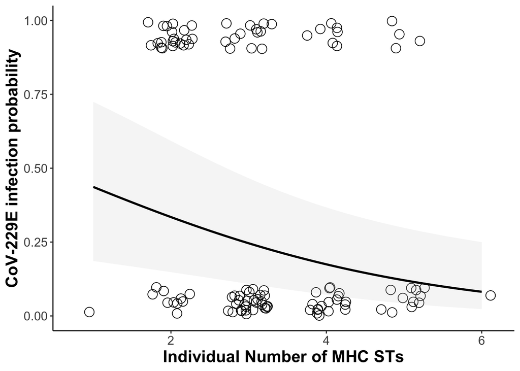

```r
#### supplementary figure on number of STs on infection probability ####
library(effects)
dat.effects <- as.data.frame(effect("number_ST", mod = retained_model1d, xlevels = list(number_ST = seq(1, 6, length.out = 100))))

  ggplot()+
  geom_jitter(data = HipD, aes(x = number_ST, y = CoV.229E), shape=21, size=4, width=.3, height = .1) +
  geom_ribbon(data = dat.effects, aes(x = number_ST, ymin = lower, ymax = upper), alpha = 0.2, fill="lightgrey") + ylim(0,1)+
  geom_line(data = dat.effects, aes(x = number_ST, y = fit), size=1) +
  theme_classic()+
  theme(legend.position = c("none")) +
  xlab("Individual Number of MHC STs")+
  ylab("CoV-229E infection probability") +
  theme(axis.title=element_text(face="bold", size=16), axis.text = element_text(size = 12))
```

```r
#CoV-2B

model8d<-(glmer(CoV.2B ~ number_ST+ number_ST2+ ST12 +(1|sample_period), data=HipD, family = binomial, na.action = na.fail))
dredge(model8d)
```

```
## Fixed term is "(Intercept)"
```

```
## Global model call: glmer(formula = CoV.2B ~ number_ST + number_ST2 + ST12 + (1 |
##     sample_period), data = HipD, family = binomial, na.action = na.fail)
## ---
## Model selection table
##     (Int)  nmb_ST  nmb_ST2    ST1 df   logLik  AICc delta weight
## 5  0.3183                  -2.022  3 -134.814 275.7  0.00  0.329
## 7 -0.1178          0.03253 -2.007  4 -133.887 275.9  0.22  0.295
## 6 -0.4465  0.2149          -1.986  4 -133.989 276.2  0.42  0.266
## 8  0.3870 -0.3007  0.07472 -2.038  5 -133.837 277.9  2.20  0.109
## 2 -1.1650  0.2904                  3 -150.224 306.6 30.82  0.000
## 3 -0.6584          0.03858         3 -150.554 307.2 31.48  0.000
## 4 -2.1870  0.9534 -0.09857         4 -149.892 308.0 32.23  0.000
## 1 -0.1641                          2 -152.079 308.2 32.48  0.000
## Models ranked by AICc(x)
## Random terms (all models):
##   1 | sample_period
```

```r
retained_model8d<-(glmer(CoV.2B ~  ST12 +(1|sample_period), data=HipD, family = binomial, na.action = na.fail))
tab_model(retained_model8d)
```

|  | CoV.2B |  |  |
| --- | --- | --- | --- |
| Predictors | Odds Ratios | CI | p |
| (Intercept) | 1.37 | 0.47 – 4.01 | 0.560 |
| ST12 | 0.13 | 0.06 – 0.28 | **<0.001** |
| Random Effects |  |  |  |
| σ<sup>2</sup> | 3.29 |  |  |
| τ<sub>00</sub> <sub>sample_period</sub> | 2.37 |  |  |
| ICC | 0.42 |  |  |
| N <sub>sample_period</sub> | 12 |  |  |
| Observations | 236 |  |  |
| Marginal R<sup>2</sup> / Conditional R<sup>2</sup> | 0.143 / 0.501 |  |  |

```r
model9d<-(glmer(CoV.2B ~ ST11+number_ST +number_ST2+(1|sample_period), data=HipD, family = binomial, na.action = na.fail))
dredge(model9d)
```

```
## Fixed term is "(Intercept)"
```

```
## Global model call: glmer(formula = CoV.2B ~ ST11 + number_ST + number_ST2 + (1 |
##     sample_period), data = HipD, family = binomial, na.action = na.fail)
## ---
## Model selection table
##     (Int) nmb_ST   nmb_ST2   ST1 df   logLik  AICc delta weight
## 5 -1.4590                  1.605  3 -141.184 288.5  0.00  0.534
## 6 -1.5980 0.0486           1.568  4 -141.144 290.5  1.99  0.197
## 7 -1.5020         0.004831 1.581  4 -141.165 290.5  2.03  0.193
## 8 -2.1640 0.4155 -0.053720 1.554  5 -141.056 292.4  3.90  0.076
## 2 -1.1650 0.2904                  3 -150.224 306.6 18.08  0.000
## 3 -0.6584         0.038580        3 -150.554 307.2 18.74  0.000
## 4 -2.1870 0.9534 -0.098570        4 -149.892 308.0 19.49  0.000
## 1 -0.1641                         2 -152.079 308.2 19.74  0.000
## Models ranked by AICc(x)
## Random terms (all models):
##   1 | sample_period
```

```r
retained_model9d<-(glmer(CoV.2B ~ ST11+(1|sample_period), data=HipD, family = binomial, na.action = na.fail))
tab_model(retained_model9d)
```

|  | CoV.2B |  |  |
| --- | --- | --- | --- |
| Predictors | Odds Ratios | CI | p |
| (Intercept) | 0.23 | 0.08 – 0.69 | **0.008** |
| ST11 | 4.98 | 2.44 – 10.17 | **<0.001** |
| Random Effects |  |  |  |
| σ<sup>2</sup> | 3.29 |  |  |
| τ<sub>00</sub> <sub>sample_period</sub> | 1.65 |  |  |
| ICC | 0.33 |  |  |
| N <sub>sample_period</sub> | 12 |  |  |
| Observations | 236 |  |  |
| Marginal R<sup>2</sup> / Conditional R<sup>2</sup> | 0.097 / 0.398 |  |  |

```r
model10d<-(glmer(CoV.2B ~ number_ST+number_ST2+ST10 +(1|sample_period), data=HipD, family = binomial, na.action = na.fail))
dredge(model10d)
```

```
## Fixed term is "(Intercept)"
```

```
## Global model call: glmer(formula = CoV.2B ~ number_ST + number_ST2 + ST10 + (1 |
##     sample_period), data = HipD, family = binomial, na.action = na.fail)
## ---
## Model selection table
##     (Int) nmb_ST  nmb_ST2    ST1 df   logLik  AICc delta weight
## 6 -1.0600 0.2293          0.8674  4 -148.495 305.2  0.00  0.222
## 5 -0.2853                 1.0100  3 -149.613 305.3  0.17  0.205
## 7 -0.6564         0.02994 0.8900  4 -148.713 305.6  0.44  0.179
## 2 -1.1650 0.2904                  3 -150.224 306.6  1.39  0.111
## 8 -1.9280 0.7922 -0.08326 0.8509  5 -148.256 306.8  1.61  0.099
## 3 -0.6584         0.03858         3 -150.554 307.2  2.05  0.080
## 4 -2.1870 0.9534 -0.09857         4 -149.892 308.0  2.79  0.055
## 1 -0.1641                         2 -152.079 308.2  3.05  0.048
## Models ranked by AICc(x)
## Random terms (all models):
##   1 | sample_period
```

```r
retained_model10d<-(glmer(CoV.2B ~ number_ST+ST10 +(1|sample_period), data=HipD, family = binomial, na.action = na.fail))
tab_model(retained_model10d)
```

|  | CoV.2B |  |  |
| --- | --- | --- | --- |
| Predictors | Odds Ratios | CI | p |
| (Intercept) | 0.35 | 0.09 – 1.27 | 0.110 |
| number ST | 1.26 | 0.93 – 1.70 | 0.137 |
| ST10 | 2.38 | 0.94 – 6.05 | 0.068 |
| Random Effects |  |  |  |
| σ<sup>2</sup> | 3.29 |  |  |
| τ<sub>00</sub> <sub>sample_period</sub> | 1.17 |  |  |
| ICC | 0.26 |  |  |
| N <sub>sample_period</sub> | 12 |  |  |
| Observations | 236 |  |  |
| Marginal R<sup>2</sup> / Conditional R<sup>2</sup> | 0.034 / 0.287 |  |  |

```r
model11d<-(glmer(CoV.2B ~ number_ST+number_ST2+ST9 +(1|sample_period), data=HipD, family = binomial, na.action = na.fail))
dredge(model11d)
```

```
## Fixed term is "(Intercept)"
```

```
## Global model call: glmer(formula = CoV.2B ~ number_ST + number_ST2 + ST9 + (1 |
##     sample_period), data = HipD, family = binomial, na.action = na.fail)
## ---
## Model selection table
##     (Int)  nmb_ST  nmb_ST2    ST9 df   logLik  AICc delta weight
## 5  0.2760                  -2.356  3 -132.848 271.8  0.00  0.408
## 7 -0.0744          0.02613 -2.332  4 -132.293 272.8  0.96  0.253
## 6 -0.2824  0.1567          -2.314  4 -132.445 273.1  1.26  0.217
## 8  1.2890 -0.8044  0.13830 -2.447  5 -131.977 274.2  2.42  0.122
## 2 -1.1650  0.2904                  3 -150.224 306.6 34.75  0.000
## 3 -0.6584          0.03858         3 -150.554 307.2 35.41  0.000
## 4 -2.1870  0.9534 -0.09857         4 -149.892 308.0 36.16  0.000
## 1 -0.1641                          2 -152.079 308.2 36.41  0.000
## Models ranked by AICc(x)
## Random terms (all models):
##   1 | sample_period
```

```r
retained_model11d<-(glmer(CoV.2B ~ ST9 +(1|sample_period), data=HipD, family = binomial, na.action = na.fail))
tab_model(retained_model11d)
```

|  | CoV.2B |  |  |
| --- | --- | --- | --- |
| Predictors | Odds Ratios | CI | p |
| (Intercept) | 1.32 | 0.44 – 3.93 | 0.620 |
| ST9 | 0.09 | 0.04 – 0.22 | **<0.001** |
| Random Effects |  |  |  |
| σ<sup>2</sup> | 3.29 |  |  |
| τ<sub>00</sub> <sub>sample_period</sub> | 2.51 |  |  |
| ICC | 0.43 |  |  |
| N <sub>sample_period</sub> | 12 |  |  |
| Observations | 236 |  |  |
| Marginal R<sup>2</sup> / Conditional R<sup>2</sup> | 0.165 / 0.526 |  |  |

```r
model12d<-(glmer(CoV.2B ~ number_ST+number_ST2+ST5 +(1|sample_period), data=HipD, family = binomial, na.action = na.fail))
dredge(model12d)
```

```
## Fixed term is "(Intercept)"
```

```
## Global model call: glmer(formula = CoV.2B ~ number_ST + number_ST2 + ST5 + (1 |
##     sample_period), data = HipD, family = binomial, na.action = na.fail)
## ---
## Model selection table
##     (Int) nmb_ST  nmb_ST2    ST5 df   logLik  AICc delta weight
## 5 -0.3931                 1.1270  3 -148.007 302.1  0.00  0.349
## 6 -0.9791 0.1782          0.9929  4 -147.385 302.9  0.83  0.231
## 7 -0.6430         0.02138 1.0140  4 -147.594 303.4  1.24  0.188
## 8 -2.2140 0.9802 -0.11990 1.0240  5 -146.909 304.1  1.96  0.131
## 2 -1.1650 0.2904                  3 -150.224 306.6  4.43  0.038
## 3 -0.6584         0.03858         3 -150.554 307.2  5.09  0.027
## 4 -2.1870 0.9534 -0.09857         4 -149.892 308.0  5.84  0.019
## 1 -0.1641                         2 -152.079 308.2  6.09  0.017
## Models ranked by AICc(x)
## Random terms (all models):
##   1 | sample_period
```

```r
retained_model12d<-(glmer(CoV.2B ~ ST5 +(1|sample_period), data=HipD, family = binomial, na.action = na.fail))
tab_model(retained_model12d)
```

|  | CoV.2B |  |  |
| --- | --- | --- | --- |
| Predictors | Odds Ratios | CI | p |
| (Intercept) | 0.67 | 0.29 – 1.55 | 0.354 |
| ST5 | 3.09 | 1.39 – 6.86 | **0.006** |
| Random Effects |  |  |  |
| σ<sup>2</sup> | 3.29 |  |  |
| τ<sub>00</sub> <sub>sample_period</sub> | 1.25 |  |  |
| ICC | 0.28 |  |  |
| N <sub>sample_period</sub> | 12 |  |  |
| Observations | 236 |  |  |
| Marginal R<sup>2</sup> / Conditional R<sup>2</sup> | 0.038 / 0.303 |  |  |

```r
# number STs
#p.adjust(c(), method = "fdr", n = 1)
# number STs^2
#p.adjust(c(), method = "fdr", n = 1)
# STs
p.adjust(c(9.05e-08, 1.05e-05, 0.068, 6.43e-08, 0.00567), method = "fdr", n = 5)
```

```
## [1] 2.2625e-07 1.7500e-05 6.8000e-02 2.2625e-07 7.0875e-03
```

```r
#CoV-2B basal

model13d<-(glmer(CoV.2Bbasal ~ number_ST+ number_ST2+ ST1 +(1|sample_period), data=HipD, family = binomial, na.action = na.fail))
dredge(model13d)
```

```
## Fixed term is "(Intercept)"
```

```
## Global model call: glmer(formula = CoV.2Bbasal ~ number_ST + number_ST2 + ST1 +
##     (1 | sample_period), data = HipD, family = binomial, na.action = na.fail)
## ---
## Model selection table
##    (Int) nmb_ST  nmb_ST2    ST1 df   logLik  AICc delta weight
## 5 -1.909                 1.1370  3 -120.925 248.0  0.00  0.332
## 6 -2.492 0.2123          0.9295  4 -120.345 248.9  0.91  0.210
## 7 -2.107         0.02374 0.9899  4 -120.531 249.2  1.28  0.175
## 8 -4.323 1.3510 -0.15680 0.8002  5 -119.856 250.0  2.02  0.121
## 4 -5.159 2.0620 -0.23560         4 -121.502 251.2  3.22  0.066
## 2 -2.424 0.3990                  3 -122.693 251.5  3.54  0.057
## 3 -1.670         0.04902         3 -123.330 252.8  4.81  0.030
## 1 -1.024                         2 -125.433 254.9  6.97  0.010
## Models ranked by AICc(x)
## Random terms (all models):
##   1 | sample_period
```

```r
retained_model13d<-(glmer(CoV.2Bbasal ~  ST1 +(1|sample_period), data=HipD, family = binomial, na.action = na.fail))
tab_model(retained_model13d)
```

|  | CoV.2Bbasal |  |  |
| --- | --- | --- | --- |
| Predictors | Odds Ratios | CI | p |
| (Intercept) | 0.15 | 0.06 – 0.37 | **<0.001** |
| ST1 | 3.12 | 1.42 – 6.86 | **0.005** |
| Random Effects |  |  |  |
| σ<sup>2</sup> | 3.29 |  |  |
| τ<sub>00</sub> <sub>sample_period</sub> | 0.52 |  |  |
| ICC | 0.14 |  |  |
| N <sub>sample_period</sub> | 12 |  |  |
| Observations | 236 |  |  |
| Marginal R<sup>2</sup> / Conditional R<sup>2</sup> | 0.071 / 0.198 |  |  |

```r
model14d<-(glmer(CoV.2Bbasal ~ ST2+number_ST +number_ST2+(1|sample_period), data=HipD, family = binomial, na.action = na.fail))
dredge(model14d)
```

```
## Fixed term is "(Intercept)"
```

```
## Global model call: glmer(formula = CoV.2Bbasal ~ ST2 + number_ST + number_ST2 +
##     (1 | sample_period), data = HipD, family = binomial, na.action = na.fail)
## ---
## Model selection table
##    (Int) nmb_ST  nmb_ST2    ST2 df   logLik  AICc delta weight
## 4 -5.159 2.0620 -0.23560         4 -121.502 251.2  0.00  0.246
## 2 -2.424 0.3990                  3 -122.693 251.5  0.31  0.210
## 8 -4.930 1.9280 -0.22520 0.5269  5 -121.058 252.4  1.20  0.135
## 6 -2.330 0.3413          0.5745  4 -122.160 252.5  1.32  0.127
## 3 -1.670         0.04902         3 -123.330 252.8  1.59  0.111
## 7 -1.679         0.04063 0.6360  4 -122.673 253.5  2.34  0.076
## 5 -1.201                 0.9031  3 -123.990 254.1  2.91  0.057
## 1 -1.024                         2 -125.433 254.9  3.74  0.038
## Models ranked by AICc(x)
## Random terms (all models):
##   1 | sample_period
```

```r
retained_model14d<-(glmer(CoV.2Bbasal ~ number_ST+number_ST2+(1|sample_period), data=HipD, family = binomial, na.action = na.fail))
tab_model(retained_model14d)
```

|  | CoV.2Bbasal |  |  |
| --- | --- | --- | --- |
| Predictors | Odds Ratios | CI | p |
| (Intercept) | 0.01 | 0.00 – 0.30 | **0.011** |
| number ST | 7.86 | 0.83 – 74.73 | 0.073 |
| number ST2 | 0.79 | 0.58 – 1.08 | 0.142 |
| Random Effects |  |  |  |
| σ<sup>2</sup> | 3.29 |  |  |
| τ<sub>00</sub> <sub>sample_period</sub> | 0.67 |  |  |
| ICC | 0.17 |  |  |
| N <sub>sample_period</sub> | 12 |  |  |
| Observations | 236 |  |  |
| Marginal R<sup>2</sup> / Conditional R<sup>2</sup> | 0.070 / 0.227 |  |  |

```r
model15d<-(glmer(CoV.2Bbasal ~ number_ST+number_ST2+ST8 +(1|sample_period), data=HipD, family = binomial, na.action = na.fail))
dredge(model15d)
```

```
## Fixed term is "(Intercept)"
```

```
## Global model call: glmer(formula = CoV.2Bbasal ~ number_ST + number_ST2 + ST8 +
##     (1 | sample_period), data = HipD, family = binomial, na.action = na.fail)
## ---
## Model selection table
##    (Int) nmb_ST  nmb_ST2    ST8 df   logLik  AICc delta weight
## 4 -5.159 2.0620 -0.23560         4 -121.502 251.2  0.00  0.195
## 5 -1.462                 0.7821  3 -122.607 251.3  0.14  0.181
## 2 -2.424 0.3990                  3 -122.693 251.5  0.31  0.166
## 6 -2.187 0.2507          0.5052  4 -121.904 252.0  0.81  0.130
## 8 -4.658 1.7560 -0.20920 0.4002  5 -120.997 252.3  1.08  0.113
## 7 -1.697         0.02600 0.5904  4 -122.202 252.6  1.40  0.097
## 3 -1.670         0.04902         3 -123.330 252.8  1.59  0.088
## 1 -1.024                         2 -125.433 254.9  3.74  0.030
## Models ranked by AICc(x)
## Random terms (all models):
##   1 | sample_period
```

```r
retained_model15d<-(glmer(CoV.2Bbasal ~ number_ST+number_ST2 +(1|sample_period), data=HipD, family = binomial, na.action = na.fail))
tab_model(retained_model15d)
```

|  | CoV.2Bbasal |  |  |
| --- | --- | --- | --- |
| Predictors | Odds Ratios | CI | p |
| (Intercept) | 0.01 | 0.00 – 0.30 | **0.011** |
| number ST | 7.86 | 0.83 – 74.73 | 0.073 |
| number ST2 | 0.79 | 0.58 – 1.08 | 0.142 |
| Random Effects |  |  |  |
| σ<sup>2</sup> | 3.29 |  |  |
| τ<sub>00</sub> <sub>sample_period</sub> | 0.67 |  |  |
| ICC | 0.17 |  |  |
| N <sub>sample_period</sub> | 12 |  |  |
| Observations | 236 |  |  |
| Marginal R<sup>2</sup> / Conditional R<sup>2</sup> | 0.070 / 0.227 |  |  |

```r
model16d<-(glmer(CoV.2Bbasal ~ number_ST+number_ST2+ST9 +(1|sample_period), data=HipD, family = binomial, na.action = na.fail))
dredge(model16d)
```

```
## Fixed term is "(Intercept)"
```

```
## Global model call: glmer(formula = CoV.2Bbasal ~ number_ST + number_ST2 + ST9 +
##     (1 | sample_period), data = HipD, family = binomial, na.action = na.fail)
## ---
## Model selection table
##     (Int) nmb_ST  nmb_ST2    ST9 df   logLik  AICc delta weight
## 6 -1.9710 0.3207          -1.509  4 -117.421 243.0  0.00  0.339
## 7 -1.3920         0.04283 -1.556  4 -117.564 243.3  0.29  0.294
## 5 -0.7687                 -1.616  3 -118.858 243.8  0.80  0.227
## 8 -2.6190 0.7100 -0.05547 -1.451  5 -117.358 245.0  1.96  0.127
## 4 -5.1590 2.0620 -0.23560         4 -121.502 251.2  8.16  0.006
## 2 -2.4240 0.3990                  3 -122.693 251.5  8.48  0.005
## 3 -1.6700         0.04902         3 -123.330 252.8  9.75  0.003
## 1 -1.0240                         2 -125.433 254.9 11.90  0.001
## Models ranked by AICc(x)
## Random terms (all models):
##   1 | sample_period
```

```r
retained_model16d<-(glmer(CoV.2Bbasal ~ ST9 +number_ST+(1|sample_period), data=HipD, family = binomial, na.action = na.fail))
tab_model(retained_model16d)
```

|  | CoV.2Bbasal |  |  |
| --- | --- | --- | --- |
| Predictors | Odds Ratios | CI | p |
| (Intercept) | 0.14 | 0.03 – 0.61 | **0.009** |
| ST9 | 0.22 | 0.08 – 0.61 | **0.003** |
| number ST | 1.38 | 0.95 – 1.99 | 0.088 |
| Random Effects |  |  |  |
| σ<sup>2</sup> | 3.29 |  |  |
| τ<sub>00</sub> <sub>sample_period</sub> | 0.12 |  |  |
| ICC | 0.04 |  |  |
| N <sub>sample_period</sub> | 12 |  |  |
| Observations | 236 |  |  |
| Marginal R<sup>2</sup> / Conditional R<sup>2</sup> | 0.162 / 0.193 |  |  |

```r
# number STs
p.adjust(c(0.0728,0.0728, 0.088), method = "fdr", n = 3)
```

```
## [1] 0.088 0.088 0.088
```

```r
# number STs^2
p.adjust(c(0.1423, 0.1423), method = "fdr", n = 2)
```

```
## [1] 0.1423 0.1423
```

```r
# STs
p.adjust(c(0.00468, 0.003), method = "fdr", n = 2)
```

```
## [1] 0.00468 0.00468
```

```r
####### Hipposideros caffer C ######
#CoV-229E

model1c<-(glmer(CoV.229E ~ number_ST + number_ST2 + ST12 +(1|sample_period), data=HipC, family = binomial, na.action = na.fail))
dredge(model1c)
```

```
## Fixed term is "(Intercept)"
```

```
## Global model call: glmer(formula = CoV.229E ~ number_ST + number_ST2 + ST12 + (1 |
##     sample_period), data = HipC, family = binomial, na.action = na.fail)
## ---
## Model selection table
##      (Int)  nmb_ST   nmb_ST2   ST1 df  logLik  AICc delta weight
## 5 -2.15800                   2.484  3 -54.087 114.3  0.00  0.385
## 7 -1.60800         -0.036090 2.388  4 -53.369 115.0  0.68  0.274
## 6 -1.31700 -0.2237           2.369  4 -53.548 115.4  1.04  0.229
## 8 -2.54000  0.5578 -0.112300 2.469  5 -53.205 116.8  2.49  0.111
## 2  0.10470 -0.3727                  3 -62.069 130.3 15.96  0.000
## 3 -0.47680         -0.052440        3 -62.133 130.4 16.09  0.000
## 1 -1.21200                          2 -63.802 131.7 17.34  0.000
## 4  0.04087 -0.3292 -0.006402        4 -62.067 132.4 18.08  0.000
## Models ranked by AICc(x)
## Random terms (all models):
##   1 | sample_period
```

```r
retained_model1c<-(glmer(CoV.229E ~  ST12 +(1|sample_period), data=HipC, family = binomial, na.action = na.fail))
tab_model(retained_model1c)
```

|  | CoV.229E |  |  |
| --- | --- | --- | --- |
| Predictors | Odds Ratios | CI | p |
| (Intercept) | 0.12 | 0.03 – 0.45 | **0.002** |
| ST12 | 11.99 | 3.76 – 38.17 | **<0.001** |
| Random Effects |  |  |  |
| σ<sup>2</sup> | 3.29 |  |  |
| τ<sub>00</sub> <sub>sample_period</sub> | 2.64 |  |  |
| ICC | 0.44 |  |  |
| N <sub>sample_period</sub> | 10 |  |  |
| Observations | 146 |  |  |
| Marginal R<sup>2</sup> / Conditional R<sup>2</sup> | 0.175 / 0.542 |  |  |

```r
model2c<-(glmer(CoV.229E ~ number_ST + number_ST2 + ST10 +(1|sample_period), data=HipC, family = binomial, na.action = na.fail))
dredge(model2c)
```

```
## Fixed term is "(Intercept)"
```

```
## Global model call: glmer(formula = CoV.229E ~ number_ST + number_ST2 + ST10 + (1 |
##     sample_period), data = HipC, family = binomial, na.action = na.fail)
## ---
## Model selection table
##      (Int)  nmb_ST   nmb_ST2     ST1 df  logLik  AICc delta weight
## 2  0.10470 -0.3727                    3 -62.069 130.3  0.00  0.243
## 3 -0.47680         -0.052440          3 -62.133 130.4  0.13  0.228
## 1 -1.21200                            2 -63.802 131.7  1.38  0.122
## 7 -0.23440         -0.056180 -0.4673  4 -61.755 131.8  1.49  0.115
## 6  0.33980 -0.3920           -0.4299  4 -61.755 131.8  1.49  0.115
## 4  0.04087 -0.3292 -0.006402          4 -62.067 132.4  2.11  0.084
## 5 -1.07400                   -0.3175  3 -63.609 133.4  3.08  0.052
## 8  0.07013 -0.1991 -0.028860 -0.4581  5 -61.733 133.9  3.59  0.040
## Models ranked by AICc(x)
## Random terms (all models):
##   1 | sample_period
```

```r
retained_model2c<-(glmer(CoV.229E ~ number_ST +(1|sample_period), data=HipC, family = binomial, na.action = na.fail))
tab_model(retained_model2c)
```

|  | CoV.229E |  |  |
| --- | --- | --- | --- |
| Predictors | Odds Ratios | CI | p |
| (Intercept) | 1.11 | 0.17 – 7.34 | 0.913 |
| number ST | 0.69 | 0.47 – 1.02 | 0.063 |
| Random Effects |  |  |  |
| σ<sup>2</sup> | 3.29 |  |  |
| τ<sub>00</sub> <sub>sample_period</sub> | 3.25 |  |  |
| ICC | 0.50 |  |  |
| N <sub>sample_period</sub> | 10 |  |  |
| Observations | 146 |  |  |
| Marginal R<sup>2</sup> / Conditional R<sup>2</sup> | 0.032 / 0.513 |  |  |

```r
model3c<-(glmer(CoV.229E ~ number_ST + number_ST2 + ST7 + (1|sample_period), data=HipC, family = binomial, na.action = na.fail))
dredge(model3c)
```

```
## Fixed term is "(Intercept)"
```

```
## Global model call: glmer(formula = CoV.229E ~ number_ST + number_ST2 + ST7 + (1 |
##     sample_period), data = HipC, family = binomial, na.action = na.fail)
## ---
## Model selection table
##      (Int)  nmb_ST   nmb_ST2    ST7 df  logLik  AICc delta weight
## 5 -0.56670                   -1.615  3 -59.059 124.3  0.00  0.489
## 6 -0.21110 -0.1132           -1.477  4 -58.939 126.2  1.87  0.191
## 7 -0.42770         -0.012420 -1.503  4 -58.989 126.3  1.97  0.182
## 8  0.29690 -0.4567  0.051070 -1.521  5 -58.861 128.2  3.86  0.071
## 2  0.10470 -0.3727                   3 -62.069 130.3  6.02  0.024
## 3 -0.47680         -0.052440         3 -62.133 130.4  6.15  0.023
## 1 -1.21200                           2 -63.802 131.7  7.40  0.012
## 4  0.04087 -0.3292 -0.006402         4 -62.067 132.4  8.13  0.008
## Models ranked by AICc(x)
## Random terms (all models):
##   1 | sample_period
```

```r
retained_model3c<-(glmer(CoV.229E ~ ST7 + (1|sample_period), data=HipC, family = binomial, na.action = na.fail))
tab_model(retained_model3c)
```

|  | CoV.229E |  |  |
| --- | --- | --- | --- |
| Predictors | Odds Ratios | CI | p |
| (Intercept) | 0.57 | 0.56 – 0.57 | **<0.001** |
| ST7 | 0.20 | 0.20 – 0.20 | **<0.001** |
| Random Effects |  |  |  |
| σ<sup>2</sup> | 3.29 |  |  |
| τ<sub>00</sub> <sub>sample_period</sub> | 2.77 |  |  |
| ICC | 0.46 |  |  |
| N <sub>sample_period</sub> | 10 |  |  |
| Observations | 146 |  |  |
| Marginal R<sup>2</sup> / Conditional R<sup>2</sup> | 0.098 / 0.510 |  |  |

```r
model4c<-(glmer(CoV.229E ~ number_ST + number_ST2 + ST1 + (1|sample_period), data=HipC, family = binomial, na.action = na.fail)) #0.43513
dredge(model4c)
```

```
## Fixed term is "(Intercept)"
```

```
## Global model call: glmer(formula = CoV.229E ~ number_ST + number_ST2 + ST1 + (1 |
##     sample_period), data = HipC, family = binomial, na.action = na.fail)
## ---
## Model selection table
##      (Int)  nmb_ST   nmb_ST2     ST1 df  logLik  AICc delta weight
## 5 -0.86520                   -1.2750  3 -61.360 128.9  0.00  0.278
## 6 -0.19790 -0.2104           -0.9722  4 -60.945 130.2  1.28  0.146
## 7 -0.52320         -0.030390 -1.0020  4 -60.959 130.2  1.31  0.144
## 2  0.10470 -0.3727                    3 -62.069 130.3  1.42  0.137
## 3 -0.47680         -0.052440          3 -62.133 130.4  1.54  0.128
## 1 -1.21200                            2 -63.802 131.7  2.80  0.069
## 8 -0.26620 -0.1634 -0.006993 -0.9717  5 -60.943 132.3  3.43  0.050
## 4  0.04087 -0.3292 -0.006402          4 -62.067 132.4  3.53  0.048
## Models ranked by AICc(x)
## Random terms (all models):
##   1 | sample_period
```

```r
retained_model4c<-(glmer(CoV.229E ~ ST1 + (1|sample_period), data=HipC, family = binomial, na.action = na.fail))
tab_model(retained_model4c)
```

|  | CoV.229E |  |  |
| --- | --- | --- | --- |
| Predictors | Odds Ratios | CI | p |
| (Intercept) | 0.42 | 0.42 – 0.42 | **<0.001** |
| ST1 | 0.28 | 0.28 – 0.28 | **<0.001** |
| Random Effects |  |  |  |
| σ<sup>2</sup> | 3.29 |  |  |
| τ<sub>00</sub> <sub>sample_period</sub> | 3.08 |  |  |
| ICC | 0.48 |  |  |
| N <sub>sample_period</sub> | 10 |  |  |
| Observations | 146 |  |  |
| Marginal R<sup>2</sup> / Conditional R<sup>2</sup> | 0.054 / 0.511 |  |  |

```r
# number STs
#p.adjust(c(), method = "fdr", n = 7)
# number STs^2
#p.adjust(c(), method = "fdr", n = 5)
# STs
#p.adjust(c(), method = "fdr", n = 3)

#CoV-2B

model4c<-(glmer(CoV.2B ~ number_ST + number_ST2 + ST1 + (1|sample_period), data=HipC, family = binomial, na.action = na.fail)) #0.43513
dredge(model4c)
```

```
## Fixed term is "(Intercept)"
```

```
## Global model call: glmer(formula = CoV.2B ~ number_ST + number_ST2 + ST1 + (1 |
##     sample_period), data = HipC, family = binomial, na.action = na.fail)
## ---
## Model selection table
##     (Int)   nmb_ST nmb_ST2    ST1 df  logLik  AICc delta weight
## 5 -2.2530                  1.0250  3 -57.906 122.0  0.00  0.319
## 7 -2.4090          0.01352 0.8828  4 -57.804 123.9  1.91  0.123
## 3 -2.3810          0.03551         3 -58.924 124.0  2.04  0.115
## 1 -1.8170                          2 -59.969 124.0  2.04  0.115
## 6 -2.3690  0.03657         0.9718  4 -57.894 124.1  2.09  0.112
## 2 -2.7260  0.24170                 3 -59.191 124.6  2.57  0.088
## 8 -0.7585 -0.94980 0.12960 1.0510  5 -57.216 124.9  2.88  0.075
## 4 -1.2390 -0.64410 0.11620         4 -58.638 125.6  3.58  0.053
## Models ranked by AICc(x)
## Random terms (all models):
##   1 | sample_period
```

```r
retained_model4c<-(glmer(CoV.2B ~ ST1 + (1|sample_period), data=HipC, family = binomial, na.action = na.fail))
tab_model(retained_model4c)
```

|  | CoV.2B |  |  |
| --- | --- | --- | --- |
| Predictors | Odds Ratios | CI | p |
| (Intercept) | 0.11 | 0.05 – 0.24 | **<0.001** |
| ST1 | 2.79 | 1.03 – 7.55 | **0.044** |
| Random Effects |  |  |  |
| σ<sup>2</sup> | 3.29 |  |  |
| τ<sub>00</sub> <sub>sample_period</sub> | 0.29 |  |  |
| ICC | 0.08 |  |  |
| N <sub>sample_period</sub> | 10 |  |  |
| Observations | 146 |  |  |
| Marginal R<sup>2</sup> / Conditional R<sup>2</sup> | 0.062 / 0.139 |  |  |

```r
# number STs
#p.adjust(c(), method = "fdr", n = 7)
# number STs^2
#p.adjust(c(), method = "fdr", n = 5)
# STs
#p.adjust(c(), method = "fdr", n = 2)
```

co-infection hypothesis

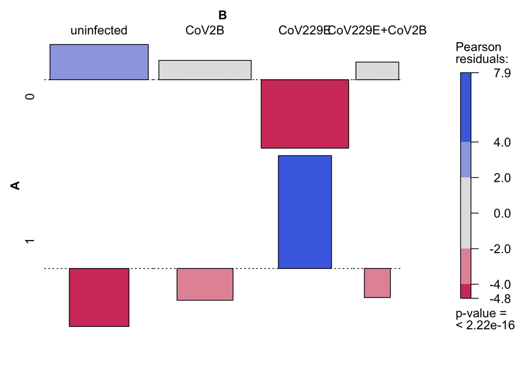

```r
### load library specific to this section
library("vcd")
bats$coinfection2 = as.factor(
  paste(bats$CoV.229E,bats$CoV.2B,bats$CoV.2Bbasal,sep="")
)
#levels(sample_data(bats)$coinfection2)
levels(bats$coinfection2) = c("uninfected", "CoV2Bbasal",
                              "CoV2B", "CoV2Bbasal+CoV2B",
                              "CoV229E","CoV229E+CoV2Bbasal",
                              "CoV229E+CoV2B", "CoV229E+CoV2B+CoV2Bbasal")

#### given the distinct, i.e. pleiotropic, effects observed in bats (Hip D) with
#### ST12 (susceptible to 229E, resistant to CoV2B)
#### we can hypothesise that co-infection with 229E and CoV2B
#### should be particularly uncommon amongst individuals with e.g. ST12

#Hypothesis: fewer individuals with ST12 should be co-infected with CoV2B and 229E

### setting up table with relevant comparisons ###
con.table <- table(bats$ST12, bats$coinfection2)
ST12_only229E.2B<-con.table[,-c(2,4,6,8)]

assoc(ST12_only229E.2B, shade = TRUE, las=3)
```

```r
#### this confirms that fewer individuals with ST12 are
#### a) uninfected, CoV2B infected or co-infected
#### but b) more individuals are singly infected with CoV229E
```

viral intensity hypothesis and Figure 3B

```r
### load library specific to this section
library(ggsignif)

####setting up labels
bats$ST12.labels <- factor(as.factor(bats$ST12), levels = c("0", "1"),
                  labels = c("MHC ST12 absent", "MHC ST12 present"))


### we test in a subset of CoV229E infected individuals whether individuals with ST12 ...
### are more severely infected based on the CT-value
subset229E<-subset(bats, CoV.229E == 1 )

wilcox.test(X229Elike ~ ST12, data=subset229E) # data is non-normal
```

```
##
##  Wilcoxon rank sum test with continuity correction
##
## data:  X229Elike by ST12
## W = 4784, p-value = 0.01658
## alternative hypothesis: true location shift is not equal to 0
```

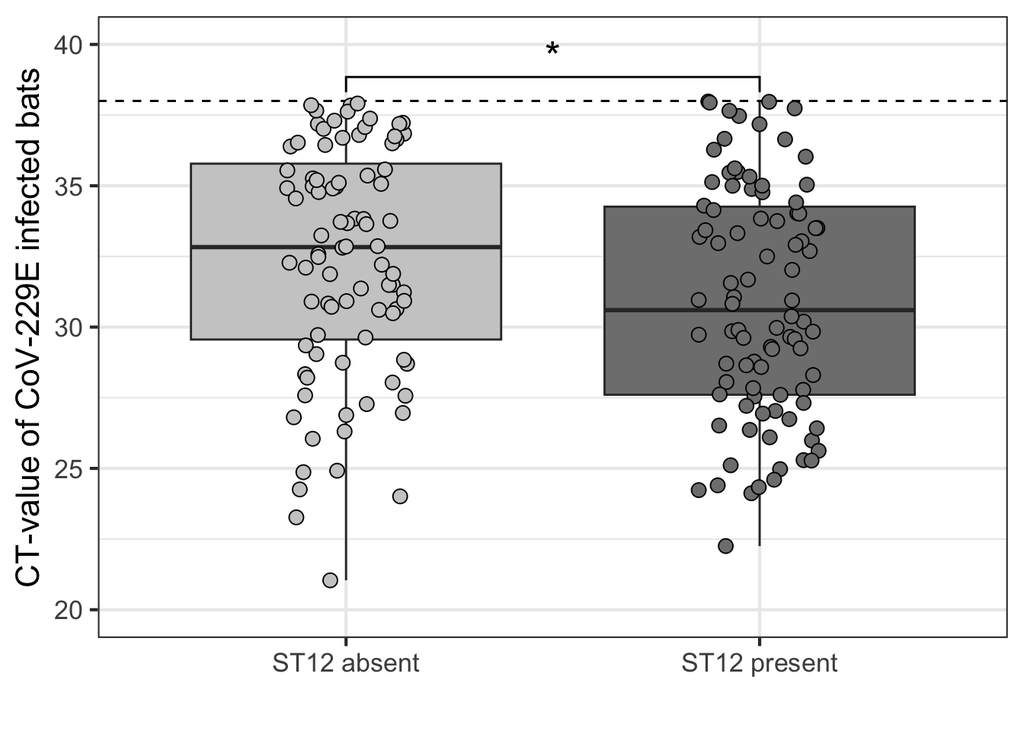

```r
ggplot(data = subset229E, aes(as.factor(ST12), X229Elike, fill = as.factor(ST12)))+
  geom_boxplot()+geom_hline(yintercept=38.0, linetype="dashed")+geom_jitter(shape=21, size=3, width = .15)+theme_bw(base_size=16)+theme(legend.position = "none")+ylim(20,40)+scale_fill_manual(values=c("grey80", "grey50"))+ylab("CT-value of CoV-229E infected bats") +geom_signif(comparisons = list(c("0", "1")), map_signif_level=TRUE, textsize = 7) + xlab("")+scale_x_discrete(labels=c("0" = "ST12 absent", "1" = "ST12 present"))
```

```r
#ggplot(data = subset229E, aes( X229Elike, fill = ST12.labels))+geom_histogram(alpha=.4, position = position_dodge(.9))+geom_vline(xintercept=38.0, linetype="dashed")+ylab("frequency")+ theme_classic(base_size=16)+theme(legend.position = c(.2,.8))+xlab("CT-value of CoV-229E infected bats")+xlim(values=c(15,38))#+scale_fill_manual(values=c("grey80", "grey50"))


### the same can be tested for CoV-2B infected; Here we predicted the opposite pattern
subset2B<-subset(bats, CoV.2B == 1)

wilcox.test(X2b ~ ST12, data=subset2B)
```

```
##
##  Wilcoxon rank sum test with continuity correction
##
## data:  X2b by ST12
## W = 3280.5, p-value = 0.1096
## alternative hypothesis: true location shift is not equal to 0
```

fitness proxy body condition/mass and Figure 4

```r
### we first calculate body condition from non-pregnant individuals
bats<-subset(bats, REP!="P" & REP!="PL") # removes pregnant females
bats<-subset(bats, Mass!="NA") # removes individuals without mass measurement
bats<-subset(bats, FA!="NA") # removes individuals without forearm length measurement

### we calculate body condition from mass divided by forearm length
bats$body.condition<-bats$Mass/bats$FA

### calculate residuals from regression between CoV229E and ST12
bats$resid_CoV229E<-resid(glm(CoV.229E~ST12, data=bats))
bats$resid_CoV2B<-resid(glm(CoV.2B~ST12, data=bats))

### initial model based on biologicallly sensible hypothesis that ...
### an interaction between ST12 and CoV229E/2B might be visible if
### a) CoV infection reduced condition and ...
### b) ST12 increases/decreases resistance/susceptibility
lm1<-(lmer(log(body.condition) ~ as.factor(ST12) * resid_CoV229E + as.factor(ST12) * resid_CoV2B+ species + number_ST  + number_ST2 +(1|sample_period), data=bats, na.action=na.fail))
dredge(lm1)
```

```
## Fixed term is "(Intercept)"
```

```
## Global model call: lmer(formula = log(body.condition) ~ as.factor(ST12) * resid_CoV229E +
##     as.factor(ST12) * resid_CoV2B + species + number_ST + number_ST2 +
##     (1 | sample_period), data = bats, na.action = na.fail)
## ---
## Model selection table
##      (Int) as.fct(ST1)   nmb_ST    nmb_ST2 rsd_CV22   rsd_CV2B spc
## 42  -1.174           +                     -0.03276              +
## 34  -1.175           +                                           +
## 58  -1.172           +                     -0.04001 -0.0295100   +
## 41  -1.179                                 -0.03196              +
## 178 -1.174           +                              -0.0365600   +
## 33  -1.179                                                       +
## 186 -1.172           +                     -0.03242 -0.0398000   +
## 36  -1.215           + 0.011650                                  +
## 35  -1.223             0.012680                                  +
```

[output cut: 203 more lines]

```r
### final model did not include interactions
retaine_lm1<-(lmer(log(body.condition) ~ as.factor(ST12) + resid_CoV229E+species +(1|sample_period), data=bats, na.action=na.fail))
tab_model(retaine_lm1)
```

|  | log(body.condition) |  |  |
| --- | --- | --- | --- |
| Predictors | Estimates | CI | p |
| (Intercept) | -1.17 | -1.20 – -1.15 | **<0.001** |
| ST12 [1] | -0.04 | -0.06 – -0.02 | **<0.001** |
| resid CoV229E | -0.03 | -0.05 – -0.01 | **0.001** |
| species [H.cf.ruberB] | -0.34 | -0.37 – -0.31 | **<0.001** |
| species [H.cf.ruberC] | -0.42 | -0.45 – -0.40 | **<0.001** |
| species [H.cf.ruberD] | -0.40 | -0.43 – -0.38 | **<0.001** |
| Random Effects |  |  |  |
| σ<sup>2</sup> | 0.01 |  |  |
| τ<sub>00</sub> <sub>sample_period</sub> | 0.00 |  |  |
| ICC | 0.02 |  |  |
| N <sub>sample_period</sub> | 12 |  |  |
| Observations | 516 |  |  |
| Marginal R<sup>2</sup> / Conditional R<sup>2</sup> | 0.731 / 0.737 |  |  |

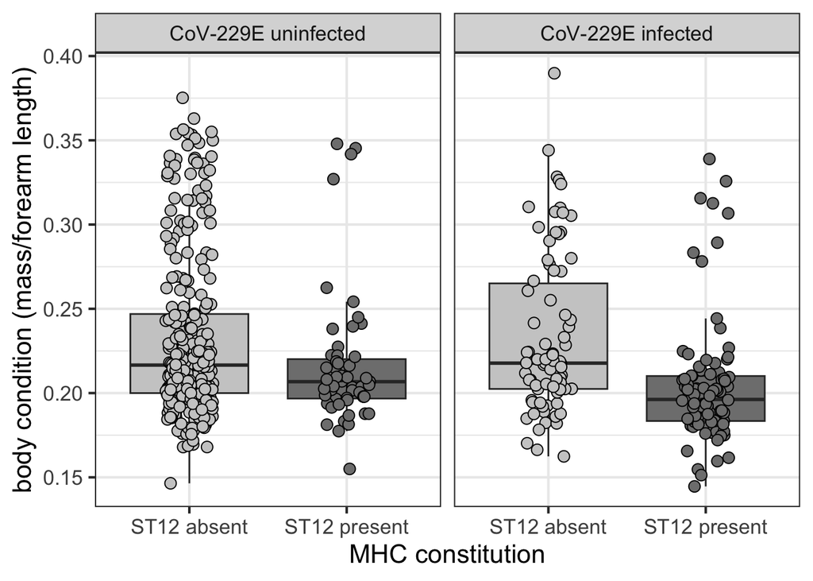

```r
#set up labelling for facet grid
bats$CoV229E.labels <- factor(as.factor(bats$CoV.229E), levels = c("0", "1"),
                  labels = c("CoV-229E uninfected", "CoV-229E infected"))

###Figure 4
ggplot(bats, aes(as.factor(ST12), body.condition, fill=as.factor(ST12)))+geom_boxplot(outlier.alpha = 0)+geom_jitter(size=3, shape =21, width=.15)+facet_grid(~CoV229E.labels)+scale_fill_manual(values=c("grey80", "grey50"))+xlab("MHC constitution")+scale_x_discrete(labels=c("0" = "ST12 absent", "1" = "ST12 present"))+theme_bw(base_size = 16)+ylab("body condition (mass/forearm length)")+theme(legend.position = "none")
```